# Deliverable 2

PCA, CA and Clustering

Júlia Gasull i Claudia Sánchez

# First setups

```r
if(!is.null(dev.list())) dev.off()  # Clear plots
rm(list=ls())                       # Clean workspace
```

## Load Required Packages for this deliverable

We load the necessary packages and set working directory

```r
#setwd("~/Documents/uni/FIB-ADEI-LAB/deliverable2")
#filepath<-"~/Documents/uni/FIB-ADEI-LAB/deliverable2"
setwd("C:/Users/Claudia Sánchez/Desktop/FIB/TARDOR 2020-2021/ADEI/DELIVERABLE1/FIB-ADEI-LAB/deliverable2")
filepath<-"C:/Users/Claudia Sánchez/Desktop/FIB/TARDOR 2020-2021/ADEI/DELIVERABLE1/FIB-ADEI-LAB/deliverable2"

# Load Required Packages
options(contrasts=c("contr.treatment","contr.treatment"))
requiredPackages <- c("missMDA","chemometrics","mvoutlier","effects","FactoMineR","car", "factoextra","RColorBrewer","dplyr","ggmap","ggthemes","knitr")
missingPackages <- requiredPackages[!(requiredPackages %in% installed.packages()[,"Package"])]
if(length(missingPackages)) install.packages(missingPackages)
lapply(requiredPackages, require, character.only = TRUE)
```

## Load processed data from first deliverable

```r
load(paste0(filepath,"/Taxi5000_del1.RData"))
```

## Clean data

```r
# remove some columns
#names(df)
df$lpep_pickup_datetime <- NULL
df$Lpep_dropoff_datetime <- NULL
df$Store_and_fwd_flag <- NULL
df$Ehail_fee <- NULL
df$CashTips <- NULL
df$Sum_total_amount <- NULL
df$yearGt2015 <- NULL

# imputation
library(missMDA)
long_lat<-names(df)[c(3:6)]
imp_long_lat<-imputePCA(df[,long_lat])
df[,long_lat]<-imp_long_lat$completeObs
```

# Principal Component Analysis (PCA)

```r
names(df)
```

```
##  [1] "VendorID"              "RateCodeID"            "Pickup_longitude"
##  [4] "Pickup_latitude"       "Dropoff_longitude"     "Dropoff_latitude"
##  [7] "Passenger_count"       "Trip_distance"         "Fare_amount"
## [10] "Extra"                 "MTA_tax"               "Tip_amount"
## [13] "Tolls_amount"          "improvement_surcharge" "Total_amount"
## [16] "Payment_type"          "Trip_type"             "hour"
## [19] "period"                "tlenkm"                "traveltime"
## [22] "espeed"                "pickup"                "dropoff"
## [25] "Trip_distance_range"   "paidTolls"             "TipIsGiven"
## [28] "passenger_groups"
```

```r
vars_res<-names(df)[c(15,27)]
vars_quantitatives<-names(df)[c(3:10,12,20:22)]
vars_categorical<-names(df)[c(1,2,16:17,19,25,28)]
```

We have already seen profiling in the previous installment. So now, let’s proceed to look at the main components.

```r
library(FactoMineR)
res.pca <- PCA(df[,c(1:10,12,13,15:17,19,21,22,25,27)],quanti.sup=c(3:6,13),quali.sup=c(1,2,14:16,19:20))
```

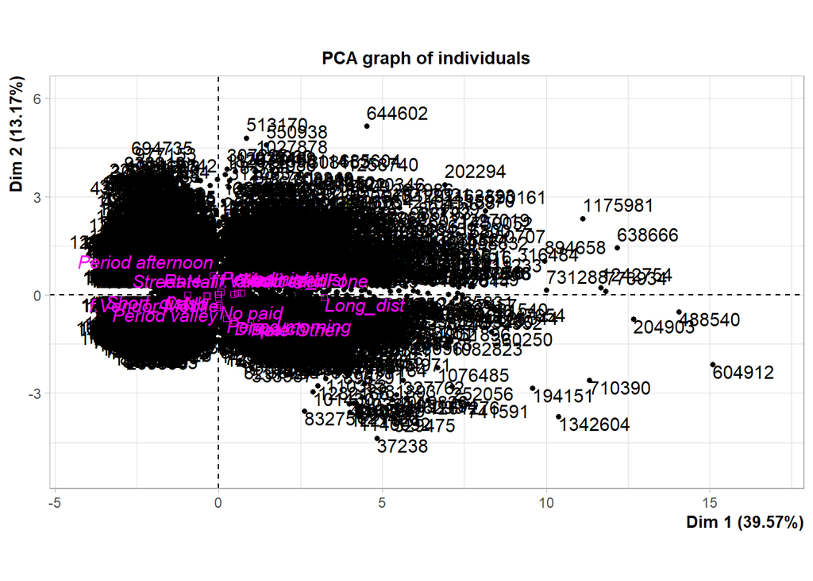

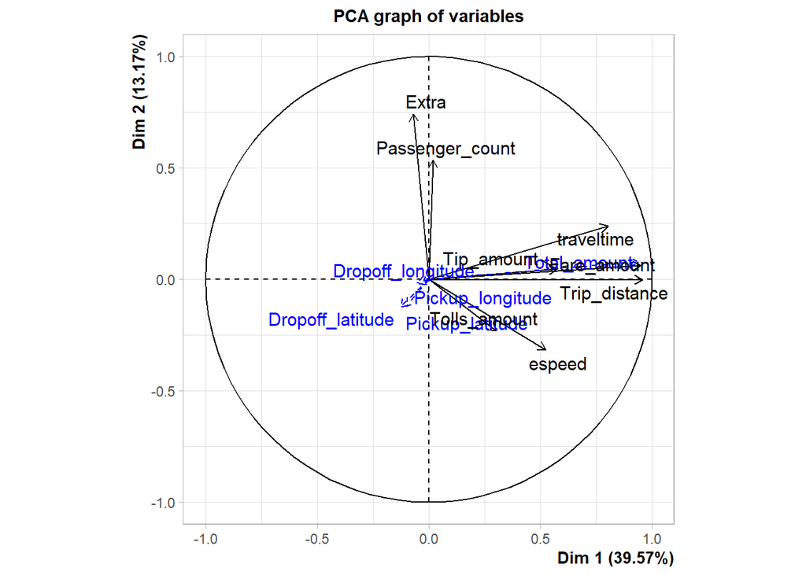

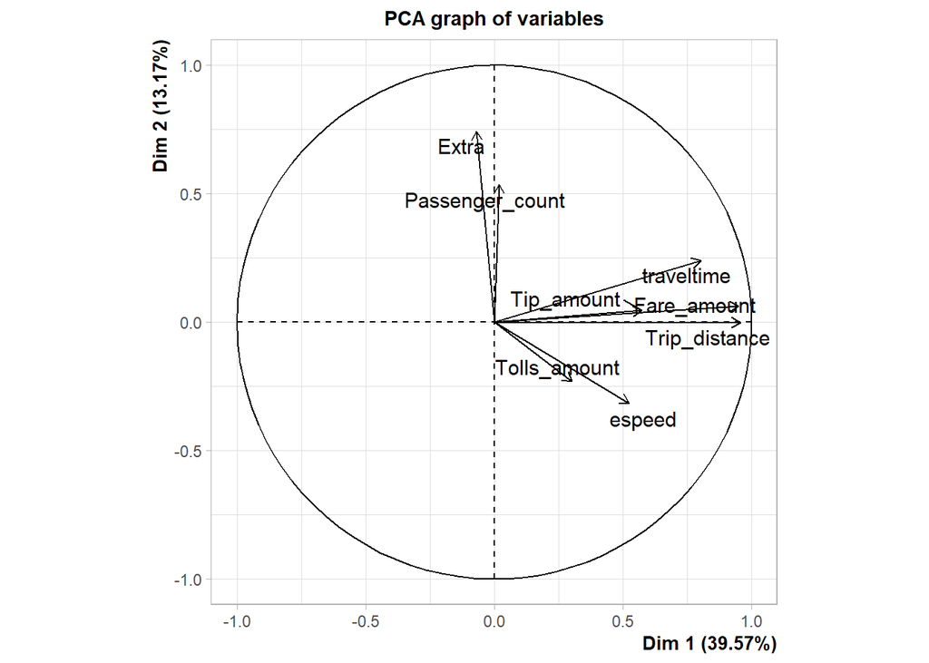

```r
plot.PCA(res.pca,choix=c("var"), invisible=c("quanti.sup"))
```

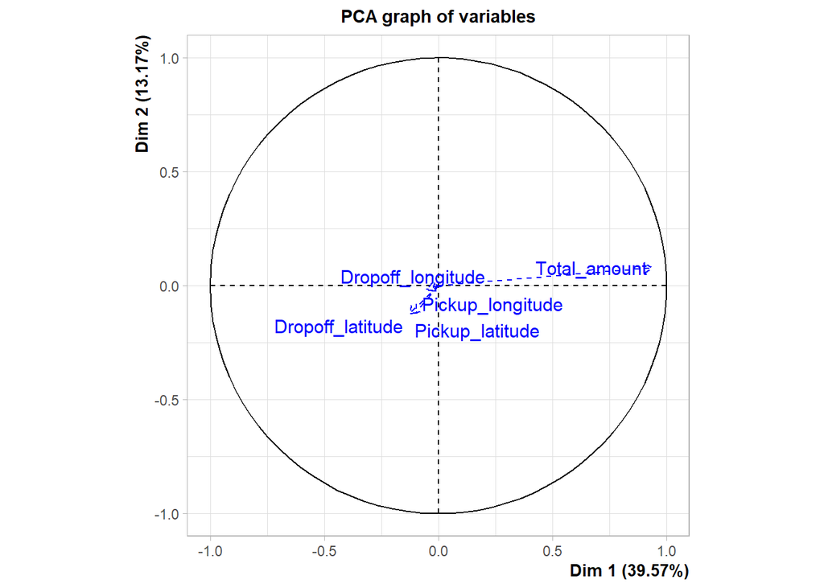

```r
plot.PCA(res.pca,choix=c("var"), invisible=c("var"))
```

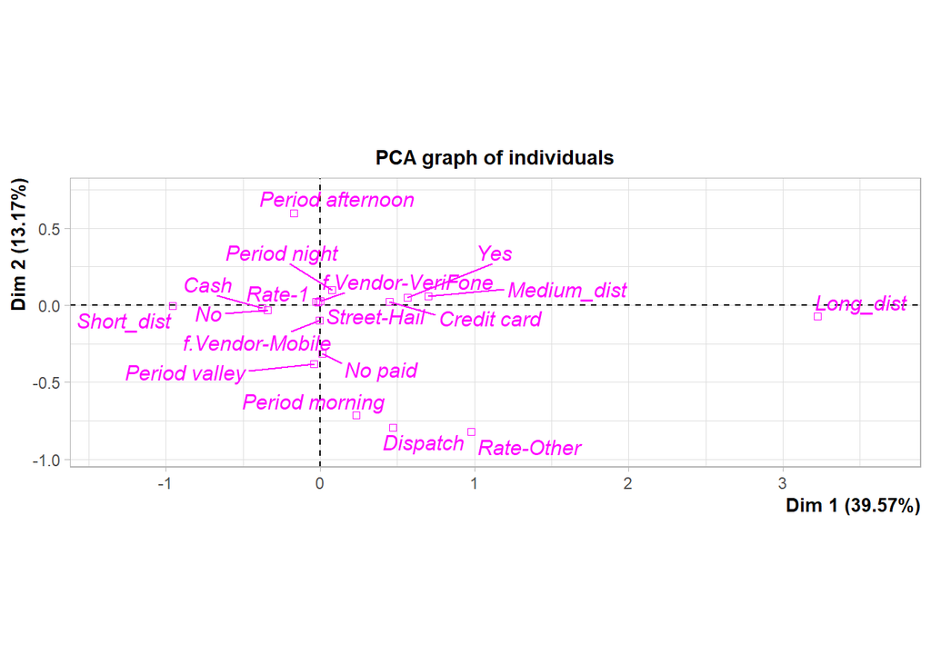

```r
plot.PCA(res.pca,choix=c("ind"), invisible=c("ind"))
```

**Multivariant outliers should be included as supplementary observations:** Since the data set we have is pretty good, we considered that we don’t have multivariate outliers

## Eigenvalues and dominant axes analysis

Eigenvalues correspond to the amount of the variation explained by each principal component (PC). Eigenvalues are large for the first PC and small for the subsequent PCs.

```r
# summary(res.pca, nb.dec=2,nbind=1, nbelements = 1000, ncp=5)
```

### How many axes we have to interpret according to Kaiser?

A PC with an eigenvalue > 1 indicates that the PC accounts for more variance than accounted by one of the original variables in standardized data. This is commonly used as a cutoff point to determine the number of PCs to retain, using the Kaiser criteria.

```r
eigenvalues <- res.pca$eig
head(eigenvalues[, 1:3])
```

```
##        eigenvalue percentage of variance cumulative percentage of variance
## comp 1  3.1654602              39.568252                          39.56825
## comp 2  1.0538386              13.172983                          52.74124
## comp 3  1.0394009              12.992511                          65.73375
## comp 4  0.9538540              11.923175                          77.65692
## comp 5  0.8970712              11.213390                          88.87031
## comp 6  0.7211678               9.014597                          97.88491
```

In this case, then, we will use up to dimension 3, and they will explain 65.73% of the total inertia.

### How many axes we have to interpret according to Elbow’s rule?

As a brief definition, we would say that the elbow rule is based on selecting dimensions until the difference in variance of that of the next factorial plane is almost the same as that of the current plane.

So let’s look at exactly where we have this minimal difference:

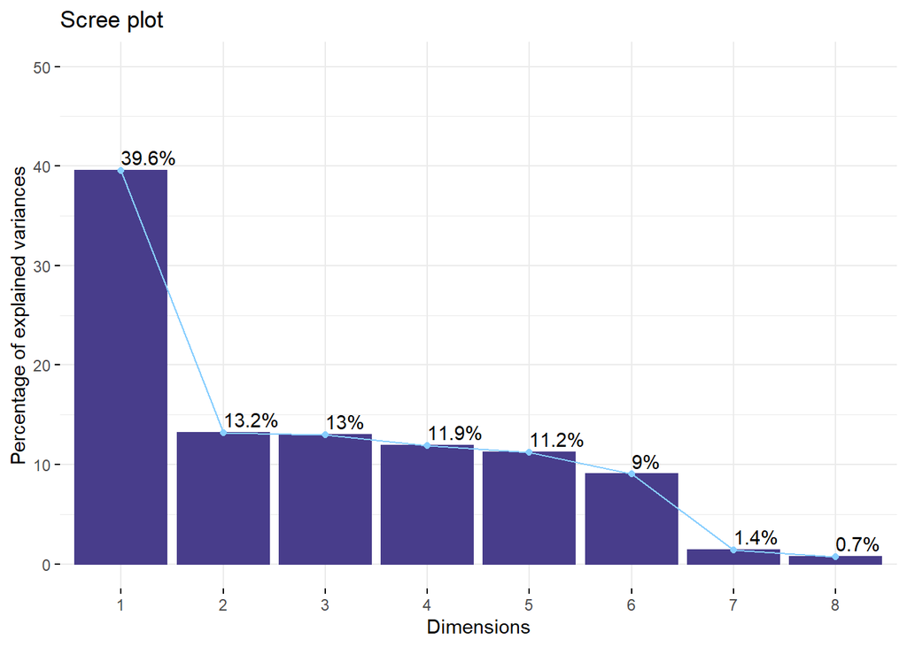

```r
fviz_screeplot(
  res.pca,
  addlabels=TRUE,
  ylim=c(0,50),
  barfill="darkslateblue",
  barcolor="darkslateblue",
  linecolor = "skyblue1"
)
```

We could say, then, that there is little difference between dimension 3 and 4, or between 5 and 6. Therefore, we could be left with 3 dimensions (as with Kasier) or 5.

## Individuals point of view

### Contribution

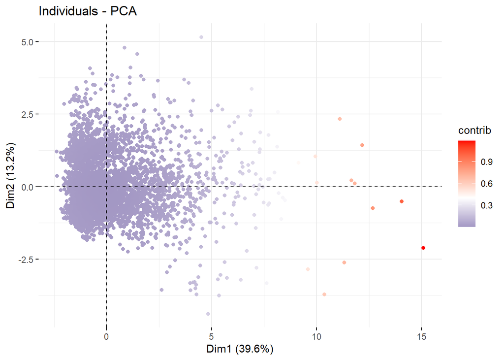

```r
# head(res.pca$ind$contrib) # contribition of individuals to the princial components
fviz_pca_ind(res.pca, col.ind="contrib", geom = "point") +
scale_color_gradient2(low="darkslateblue", mid="white",
                      high="red", midpoint=0.40)
```

We can see that there are some individuals that are too contributive. So now, let’s try to understand them better with extreme individuals.

### Extreme individuals

#### In dimension 1:

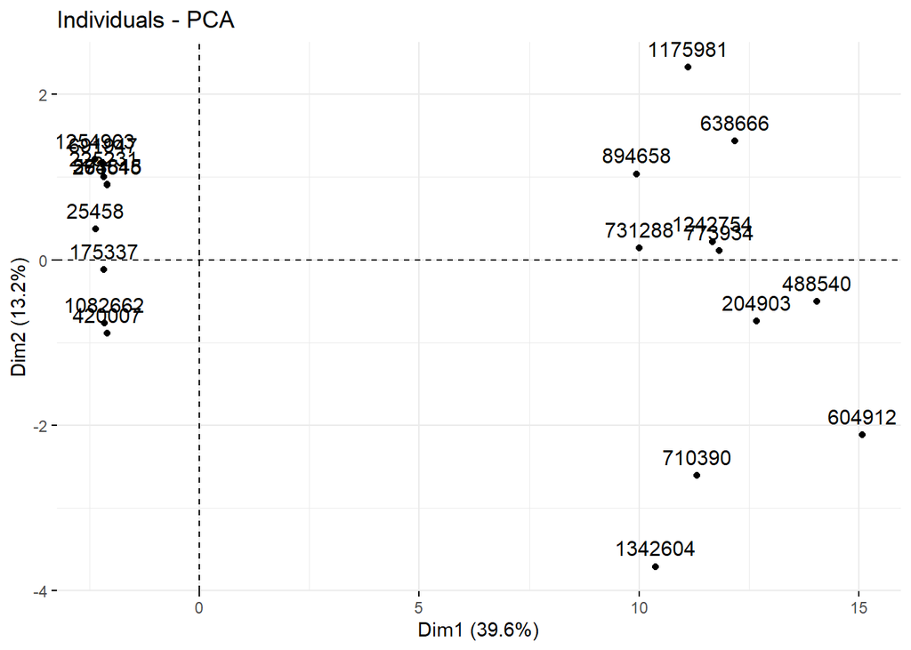

```r
rang<-order(res.pca$ind$coord[,1])
contrib.extremes<-c(row.names(df)[rang[1]], row.names(df)[rang[length(rang)]])

contrib.extremes<-c(row.names(df)[rang[1:10]], row.names(df)[rang[(length(rang)-10):length(rang)]])
fviz_pca_ind(res.pca, select.ind = list(names=contrib.extremes))
```

We can now have a look at them:

```r
df[which(row.names(df) %in% row.names(df)[rang[(length(rang)-10):length(rang)]]), 1:28]
```

```
##                  VendorID RateCodeID Pickup_longitude Pickup_latitude
## 204903    f.Vendor-Mobile     Rate-1        -73.98677        40.70252
## 488540  f.Vendor-VeriFone     Rate-1        -73.91121        40.75299
## 604912  f.Vendor-VeriFone     Rate-1        -73.81548        40.62804
## 638666  f.Vendor-VeriFone Rate-Other        -73.80701        40.69907
## 710390  f.Vendor-VeriFone     Rate-1        -73.93688        40.81975
## 731288  f.Vendor-VeriFone     Rate-1        -73.94330        40.63695
## 773934  f.Vendor-VeriFone     Rate-1        -73.95317        40.81768
## 894658    f.Vendor-Mobile     Rate-1        -73.94506        40.79953
## 1175981 f.Vendor-VeriFone     Rate-1        -73.92376        40.76116
## 1242754 f.Vendor-VeriFone     Rate-1        -73.96619        40.58548
## 1342604   f.Vendor-Mobile Rate-Other        -73.94370        40.81538
##         Dropoff_longitude Dropoff_latitude Passenger_count Trip_distance
## 204903          -73.97940         40.64393               1      27.00000
## 488540          -73.91345         40.75084               1      30.00000
```

[output cut: 57 more lines]

```r
df[which(row.names(df) %in% row.names(df)[rang[1:10]]),1:28]
```

```
##                  VendorID RateCodeID Pickup_longitude Pickup_latitude
## 25458   f.Vendor-VeriFone     Rate-1        -73.89600        40.85568
## 175337    f.Vendor-Mobile     Rate-1        -73.85332        40.72649
## 225231  f.Vendor-VeriFone     Rate-1        -73.94785        40.80964
## 263515  f.Vendor-VeriFone     Rate-1        -73.95492        40.82026
## 274645    f.Vendor-Mobile     Rate-1        -73.94057        40.62366
## 420007    f.Vendor-Mobile     Rate-1        -73.89059        40.74692
## 591818  f.Vendor-VeriFone     Rate-1        -73.97880        40.68356
## 691947  f.Vendor-VeriFone     Rate-1        -73.80762        40.70077
## 1082662 f.Vendor-VeriFone     Rate-1        -73.93958        40.81605
## 1254963 f.Vendor-VeriFone     Rate-1        -73.99031        40.69246
##         Dropoff_longitude Dropoff_latitude Passenger_count Trip_distance
## 25458           -73.89645         40.85497               1    0.05000000
## 175337          -73.85199         40.72478               2    0.10000000
## 225231          -73.94830         40.80927               1    0.04000000
```

[output cut: 51 more lines]

#### In dimension 2:

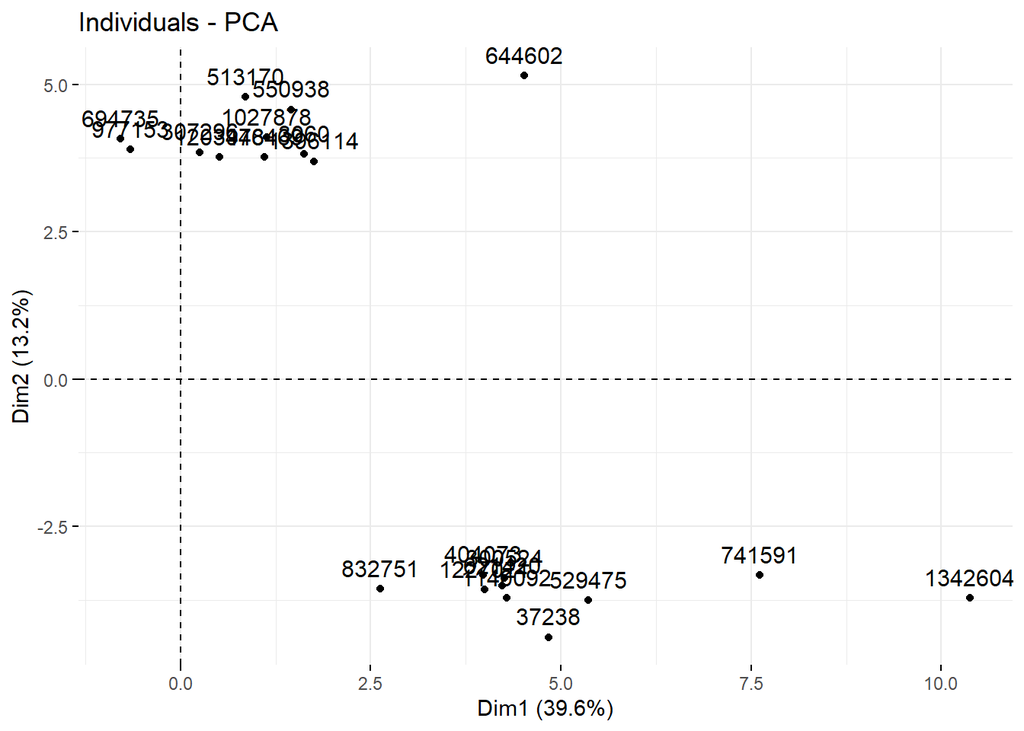

```r
rang<-order(res.pca$ind$coord[,2])
contrib.extremes<-c(row.names(df)[rang[1]], row.names(df)[rang[length(rang)]])

contrib.extremes<-c(row.names(df)[rang[1:10]], row.names(df)[rang[(length(rang)-10):length(rang)]])
fviz_pca_ind(res.pca, select.ind = list(names=contrib.extremes))
```

We can now have a look at them:

```r
df[which(row.names(df) %in% row.names(df)[rang[(length(rang)-10):length(rang)]]), 1:28]
```

```
##                  VendorID RateCodeID Pickup_longitude Pickup_latitude
## 3060    f.Vendor-VeriFone     Rate-1        -73.86355        40.73727
## 307296  f.Vendor-VeriFone     Rate-1        -73.95361        40.78796
## 513170  f.Vendor-VeriFone     Rate-1        -73.91908        40.75881
## 550938  f.Vendor-VeriFone     Rate-1        -73.93481        40.74301
## 644602  f.Vendor-VeriFone     Rate-1        -73.92159        40.76666
## 694735  f.Vendor-VeriFone     Rate-1        -73.98262        40.66566
## 976469  f.Vendor-VeriFone     Rate-1        -73.96669        40.80442
## 977153  f.Vendor-VeriFone     Rate-1        -73.89025        40.74623
## 1027878 f.Vendor-VeriFone     Rate-1        -73.96809        40.63953
## 1203448 f.Vendor-VeriFone     Rate-1        -73.97668        40.68291
## 1396114 f.Vendor-VeriFone     Rate-1        -73.96153        40.71631
##         Dropoff_longitude Dropoff_latitude Passenger_count Trip_distance
## 3060            -73.91945         40.74348               5          3.05
## 307296          -73.96581         40.76854               5          1.68
```

[output cut: 57 more lines]

```r
df[which(row.names(df) %in% row.names(df)[rang[1:10]]),1:28]
```

```
##                  VendorID RateCodeID Pickup_longitude Pickup_latitude
## 37238   f.Vendor-VeriFone     Rate-1        -73.94037        40.79722
## 300524  f.Vendor-VeriFone     Rate-1        -73.95204        40.79805
## 404073  f.Vendor-VeriFone     Rate-1        -73.92345        40.80943
## 529475  f.Vendor-VeriFone     Rate-1        -73.95724        40.81275
## 621420  f.Vendor-VeriFone     Rate-1        -73.93903        40.81678
## 741591  f.Vendor-VeriFone     Rate-1        -73.89080        40.74696
## 832751  f.Vendor-VeriFone     Rate-1        -73.98846        40.67025
## 1140092   f.Vendor-Mobile     Rate-1        -73.91059        40.76953
## 1227021 f.Vendor-VeriFone     Rate-1        -73.89172        40.74702
## 1342604   f.Vendor-Mobile Rate-Other        -73.94370        40.81538
##         Dropoff_longitude Dropoff_latitude Passenger_count Trip_distance
## 37238           -73.87116         40.77416               1          6.29
## 300524          -73.87309         40.77436               2          7.44
## 404073          -73.87628         40.76842               1          6.70
```

[output cut: 51 more lines]

### Detection of multivariant outliers and influent data.

Since we’ve commented before that we don’t consider multivariate outliers, no action should be taken here.

## Interpreting the axes: Variables point of view coordinates, quality of representation, contribution of the variables

```r
res.des <- dimdesc(res.pca)
```

### First dimension

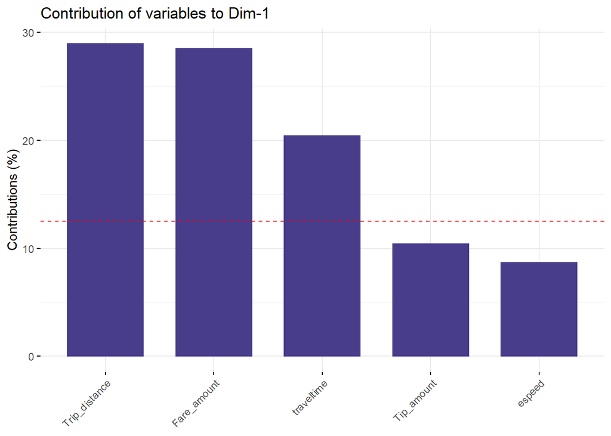

```r
fviz_contrib(  # contributions of variables to PC1
  res.pca,
  fill = "darkslateblue",
  color = "darkslateblue",
  choice = "var",
  axes = 1,
  top = 5)
```

```r
res.des$Dim.1
```

```
## $quanti
##                   correlation      p.value
## Trip_distance      0.95730706 0.000000e+00
## Fare_amount        0.94960484 0.000000e+00
## Total_amount       0.93942001 0.000000e+00
## traveltime         0.80368337 0.000000e+00
## Tip_amount         0.57415837 0.000000e+00
## espeed             0.52394674 0.000000e+00
## Tolls_amount       0.30300105 9.013310e-99
## Pickup_longitude  -0.03125024 3.360908e-02
## Dropoff_longitude -0.05426961 2.227979e-04
## Extra             -0.07041780 1.646768e-06
## Pickup_latitude   -0.10228377 3.148028e-12
## Dropoff_latitude  -0.12894697 1.345881e-18
##
## $quali
##                              R2      p.value
## Trip_distance_range 0.691017128 0.000000e+00
## TipIsGiven          0.060653567 7.774385e-65
## Payment_type        0.053034123 2.149327e-55
## RateCodeID          0.008583339 2.769847e-10
## period              0.005169311 2.569159e-05
## Trip_type           0.001738152 4.580306e-03
##
## $category
##                                    Estimate      p.value
## Trip_distance_range=Long_dist    2.23397417 0.000000e+00
## TipIsGiven=Yes                   0.45216207 7.774385e-65
## Payment_type=Credit card         0.41968655 2.271313e-56
## RateCodeID=Rate-Other            0.50422625 2.769847e-10
## period=Period morning            0.20884328 1.137211e-03
## Trip_type=Dispatch               0.24121859 4.580306e-03
## period=Period night              0.05154686 3.047979e-02
## Trip_type=Street-Hail           -0.24121859 4.580306e-03
## period=Period afternoon         -0.19586260 1.290974e-04
## RateCodeID=Rate-1               -0.50422625 2.769847e-10
## Trip_distance_range=Medium_dist -0.28824012 2.452911e-45
## Payment_type=Cash               -0.40559005 2.694846e-56
## TipIsGiven=No                   -0.45216207 7.774385e-65
## Trip_distance_range=Short_dist  -1.94573405 0.000000e+00
##
## attr(,"class")
## [1] "condes" "list "
```

In the first dimension we see that for the **quantitative** variables the most positively related, from more to less, are:

- Trip_distance (0.95)
- Fare_amount (0.94)
- Total_amount (0.93)
- traveltime (0.80)

If we take look at the **qualitatives** ones, we that the most related is

- Trip_distance_range (0.69)

Finally, if we take a look at the **categories** we see that for the Trip_distance_range category long distance trips show a mean 2.23 units over the global mean and short distance ones show a mean -1.94 units under the global mean, so we can reject the H0 done in the t.Student test.

### Second dimension

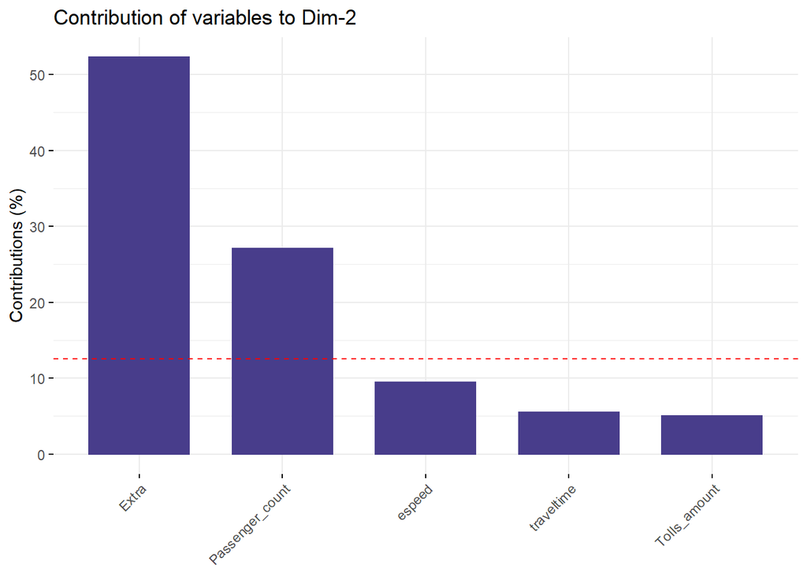

```r
fviz_contrib(  # contributions of variables to PC1
  res.pca,
  fill = "darkslateblue",
  color = "darkslateblue",
  choice = "var",
  axes = 2,
  top = 5)
```

```r
res.des$Dim.2
```

```
## $quanti
##                  correlation       p.value
## Extra             0.74258866  0.000000e+00
## Passenger_count   0.53463310  0.000000e+00
## traveltime        0.23990250  1.615918e-61
## Total_amount      0.07947291  6.278874e-08
## Fare_amount       0.06251197  2.105822e-05
## Tip_amount        0.04580469  1.838358e-03
## Pickup_latitude  -0.12147081  1.155632e-16
## Dropoff_latitude -0.12411309  2.469588e-17
## Tolls_amount     -0.23032359  1.024002e-56
## espeed           -0.31615982 7.834681e-108
##
## $quali
##                              R2       p.value
## period              0.184068800 2.143099e-203
## RateCodeID          0.018119629  3.862505e-20
## Trip_type           0.014819256  9.922508e-17
## VendorID            0.002425023  8.098907e-04
## TipIsGiven          0.001332968  1.304433e-02
## Trip_distance_range 0.001446882  3.527015e-02
##
## $category
##                                    Estimate       p.value
## period=Period afternoon          0.69741738 6.273330e-126
## RateCodeID=Rate-1                0.42270813  3.862505e-20
## Trip_type=Street-Hail            0.40639535  9.922508e-17
## period=Period night              0.19868760  1.141234e-06
## VendorID=f.Vendor-VeriFone       0.06200633  8.098907e-04
## TipIsGiven=Yes                   0.03867626  1.304433e-02
## Trip_distance_range=Medium_dist  0.06499883  4.081973e-02
## Trip_distance_range=Long_dist   -0.06734957  4.739997e-02
## TipIsGiven=No                   -0.03867626  1.304433e-02
## VendorID=f.Vendor-Mobile        -0.06200633  8.098907e-04
## Trip_type=Dispatch              -0.40639535  9.922508e-17
## RateCodeID=Rate-Other           -0.42270813  3.862505e-20
## period=Period valley            -0.28051232  5.465420e-55
## period=Period morning           -0.61559267  5.765919e-69
##
## attr(,"class")
## [1] "condes" "list "
```

For the second dimension we see that or the **quantitative** variables Extra and Passenger_count are the most positively related ones with 0.74 and 0.53 respectively.

If we see the **qualitative** variables we notice that period is the most related with 0.18 even though it is not a very remarkable data.

And we see that for this **category**, period afternoon mean is 0.69 units over the global mean and period morning mean, on the contrary, is -0.61 units under the global mean, so we can reject the H0 done in the t.Student test.

### Third dimension

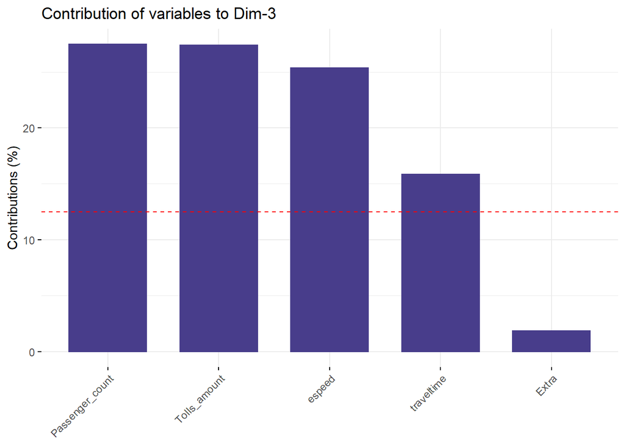

```r
fviz_contrib(  # contributions of variables to PC1
  res.pca,
  fill = "darkslateblue",
  color = "darkslateblue",
  choice = "var",
  axes = 3,
  top = 5)
```

```r
res.des$Dim.3
```

```
## $quanti
##                   correlation       p.value
## Passenger_count    0.53445793  0.000000e+00
## Tolls_amount       0.53348146  0.000000e+00
## espeed             0.51322530 3.958881e-309
## Extra              0.13832221  3.460374e-21
## Dropoff_longitude  0.08626112  4.241523e-09
## Pickup_longitude   0.07649050  1.919027e-07
## Tip_amount         0.05620014  1.317391e-04
## Dropoff_latitude   0.04007164  6.431426e-03
## Pickup_latitude    0.03744970  1.088064e-02
## Total_amount      -0.06349286  1.558600e-05
## Fare_amount       -0.13644926  1.178290e-20
## traveltime        -0.40591753 6.233710e-183
##
## $quali
##                              R2      p.value
## period              0.035886226 2.283135e-36
## Trip_distance_range 0.007909240 1.080799e-08
## TipIsGiven          0.004524510 4.707055e-06
## Payment_type        0.003949701 1.070864e-04
## VendorID            0.001086215 2.503325e-02
##
## $category
##                                     Estimate      p.value
## period=Period night              0.282886526 4.247490e-30
## TipIsGiven=Yes                   0.070766034 4.707055e-06
## Payment_type=Credit card         0.121518708 2.298510e-05
## Trip_distance_range=Short_dist   0.064024746 1.353427e-04
## VendorID=f.Vendor-VeriFone       0.041213596 2.503325e-02
## VendorID=f.Vendor-Mobile        -0.041213596 2.503325e-02
## Payment_type=Cash               -0.004578138 4.465703e-05
## TipIsGiven=No                   -0.070766034 4.707055e-06
## Trip_distance_range=Medium_dist -0.152026208 1.617657e-09
## period=Period morning           -0.205703946 2.492716e-10
## period=Period valley            -0.144508011 4.079781e-16
##
## attr(,"class")
## [1] "condes" "list "
```

For the last dimension we took into account, the third one, we see that the most related **quantitative** variables are:

- Passenger_count (0.53)
- Tolls_amount (0.53)
- espeed (0.51),

For the inversely related one, we also see that traveltime time (-0.40).

**We can conclude, then, that the first dimension is the one with the biggest correlations.**

## Perform a PCA taking into account also supplementary variables the supplementary variables can be quantitative and/or categorical

We want to take analyze the supplementary factor **kind of rate**, so we want to add lines that join the categories of this factor for the first factorial plane. With the following plot we can see it.

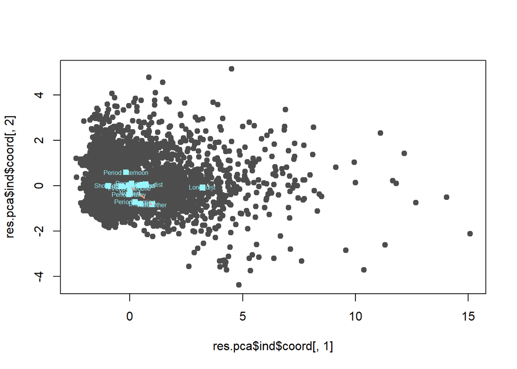

```r
plot(res.pca$ind$coord[,1],res.pca$ind$coord[,2],pch=19,col="grey30") #draw all the individuals in grey
points(res.pca$quali.sup$coord[,1],res.pca$quali.sup$coord[,2],pch=15,col="cadetblue1") # points associated with the categories gravitatorial centers
lines(res.pca$quali.sup$coord[3:4,1],res.pca$quali.sup$coord[3:4,2],lwd=2,lty=2,col="coral") # draw a line that joins the categories that we want to take a look at
text(res.pca$quali.sup$coord[,1],res.pca$quali.sup$coord[,2],labels=names(res.pca$quali.sup$coord[,1]),col="cadetblue1",cex=0.5) #add the names of the different categories
```

```r
# res.pca$quali.sup$coord
```

# Hierarchical Clustering

```r
res.hcpc <- HCPC(res.pca,nb.clust = 5, order = TRUE)
```

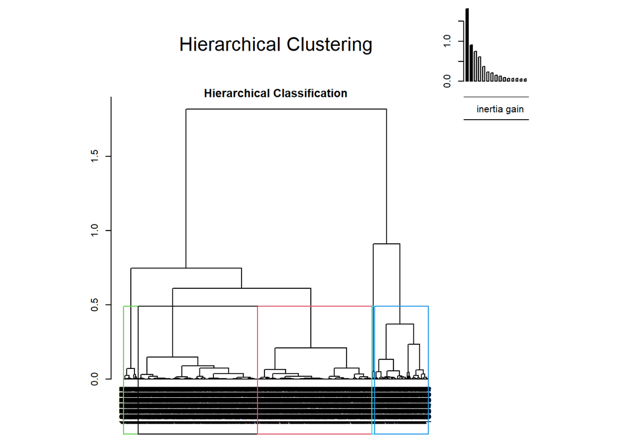

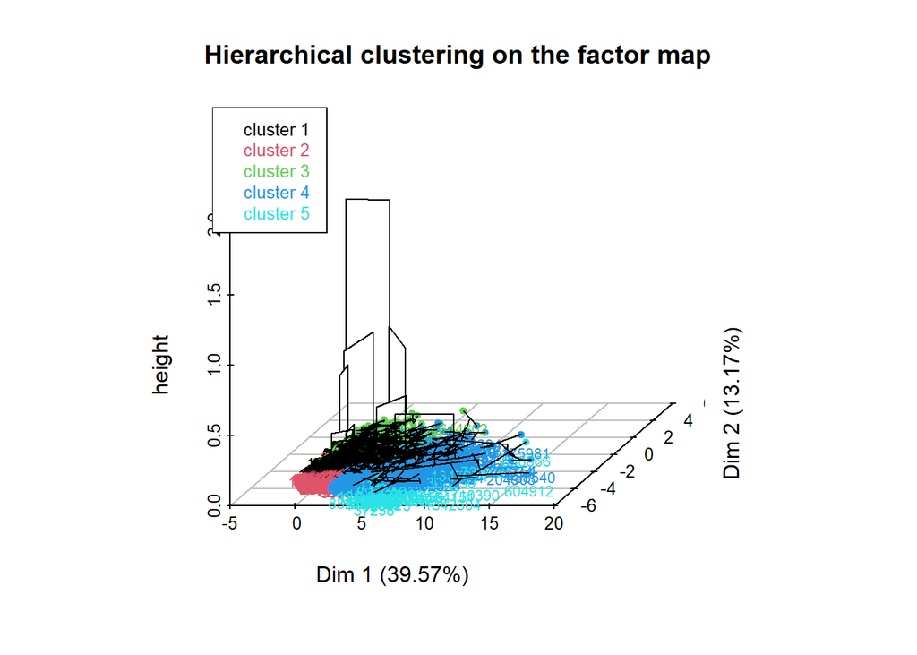

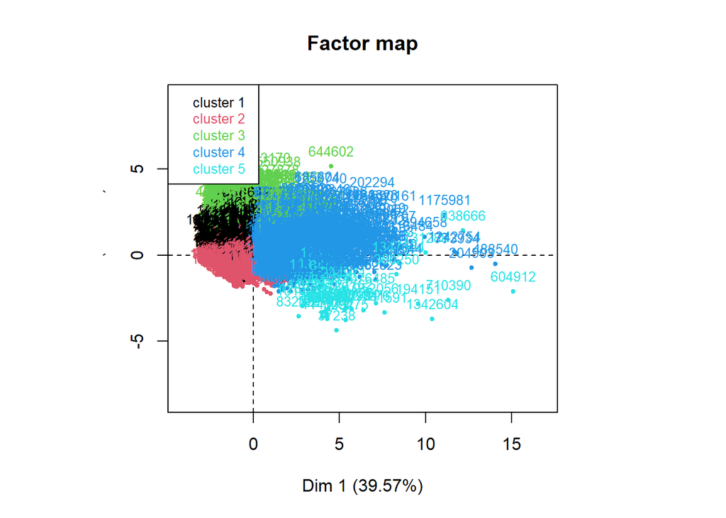

*Note*: If we chose the default number of cluster it would be 3, as we can guess from the inertia reduction plot, that follows the Elbow’s rule (number of black lines plus 1). In our case, due to the amount of data we have, the reason why we chose 5 as the number of clusters is because, after trying different numbers, we thought it was the best way to distribute the data.

## Description of clusters

Number of observations in each cluster:

```r
table(res.hcpc$data.clust$clust)
```

```
##
##    1    2    3    4    5
## 1930 1634  262  758   39
```

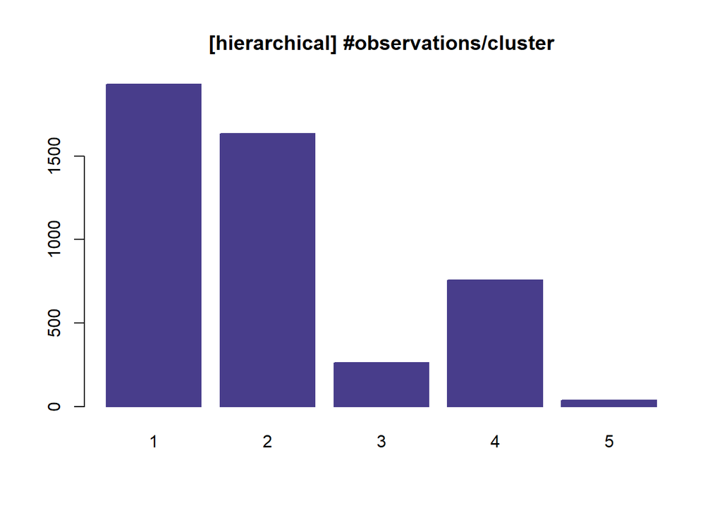

```r
barplot(table(res.hcpc$data.clust$clust), col="darkslateblue", border="darkslateblue", main="[hierarchical] #observations/cluster")
```

## Interpret the results of the classification

### The description of the clusters by the variables

```r
names(res.hcpc$desc.var)
```

```
## [1] "test.chi2"  "category"   "quanti.var" "quanti"     "call"
```

```r
res.hcpc$desc.var$test.chi2   # categorical variables which characterizes the clusters
```

```
##                          p.value df
## period              0.000000e+00 12
## Trip_distance_range 0.000000e+00  8
## TipIsGiven          4.279197e-36  4
## Payment_type        1.274689e-28  8
## RateCodeID          4.483773e-23  4
## Trip_type           1.609776e-21  4
## VendorID            2.096463e-08  4
```

We start wit the description of the categorical variables that characterize the clusters, so in this output we do not have dimensions because it is the total association. We can see the intensity of the variables, in our case the variables that affect more to the clustering are **period** and **Trip_distance_range** because are the one with the smallest p.value. The variables associated to the clusters are the ones that appear on the output.

```r
res.hcpc$desc.var$category    # description of each cluster by the categories
```

```
## $`1`
##                                   Cla/Mod      Mod/Cla    Global       p.value
## period=Period night            64.0682095  54.50777202 35.518062 7.770495e-116
## Trip_distance_range=Short_dist 50.7065949  78.08290155 64.287259  1.280121e-63
## period=Period afternoon        60.8142494  37.15025907 25.502920  6.952752e-53
## RateCodeID=Rate-1              42.9048043  99.94818653 97.252866  4.277657e-29
## Trip_type=Street-Hail          42.7843050 100.00000000 97.577331  1.936966e-27
## Payment_type=Cash              44.0128154  56.94300518 54.012546  7.116030e-04
## TipIsGiven=No                  43.6502429  65.18134715 62.340472  7.289207e-04
## Payment_type=Credit card       39.0744275  42.43523316 45.338525  7.859632e-04
## TipIsGiven=Yes                 38.5985066  34.81865285 37.659528  7.289207e-04
## Trip_type=Dispatch              0.0000000   0.00000000  2.422669  1.936966e-27
## RateCodeID=Rate-Other           0.7874016   0.05181347  2.747134  4.277657e-29
## period=Period morning           0.7380074   0.20725389 11.723989 1.260284e-129
## period=Period valley           12.4603175   8.13471503 27.255029 2.922636e-150
## Trip_distance_range=Long_dist   0.4511278   0.15544041 14.384599 2.585616e-166
##                                    v.test
## period=Period night             22.877574
## Trip_distance_range=Short_dist  16.838228
## period=Period afternoon         15.306182
## RateCodeID=Rate-1               11.195750
## Trip_type=Street-Hail           10.852664
## Payment_type=Cash                3.385069
## TipIsGiven=No                    3.378464
## Payment_type=Credit card        -3.357691
## TipIsGiven=Yes                  -3.378464
## Trip_type=Dispatch             -10.852664
## RateCodeID=Rate-Other          -11.195750
## period=Period morning          -24.223432
## period=Period valley           -26.108457
## Trip_distance_range=Long_dist  -27.485937
##
## $`2`
##                                  Cla/Mod   Mod/Cla    Global       p.value
## period=Period valley           66.587302 51.346389 27.255029 7.063369e-159
## period=Period morning          74.723247 24.785802 11.723989  1.245802e-88
## Trip_distance_range=Short_dist 42.698520 77.662179 64.287259  1.943824e-46
## Trip_type=Dispatch             73.214286  5.018360  2.422669  1.854170e-16
## RateCodeID=Rate-Other          66.141732  5.140759  2.747134  1.024771e-12
## TipIsGiven=No                  38.965996 68.727050 62.340472  2.645583e-11
```

[output cut: 74 more lines]

```
## RateCodeID=Rate-Other          3.14960630 10.256410  2.747134 2.519752e-02
## RateCodeID=Rate-1              0.77846975 89.743590 97.252866 2.519752e-02
## TipIsGiven=No                  0.38167939 28.205128 62.340472 1.783365e-05
## Payment_type=Cash              0.28033640 17.948718 54.012546 4.309549e-06
## Trip_distance_range=Short_dist 0.03364738  2.564103 64.287259 2.003816e-16
##                                   v.test
## Trip_distance_range=Long_dist   8.764351
## Payment_type=Credit card        4.675157
## TipIsGiven=Yes                  4.290419
## period=Period morning           2.795233
## RateCodeID=Rate-Other           2.238361
## RateCodeID=Rate-1              -2.238361
## TipIsGiven=No                  -4.290419
## Payment_type=Cash              -4.595866
## Trip_distance_range=Short_dist -8.221854
```

**Cluster 1**

The first thing we can notice from this cluster is that **Trip_type=Street-Hail** that intervents in the 97.58% from the sample, in this cluster is the 100% of the observations, which means that all the observations in this cluster have this type of trip. We have 42.78% from the Trip_type=Street-Hail observations in this cluster. As we can see and expect, from the other trip_type that we have in this cluster is that **Trip_type=Dispatch** that intervents in the 2.42% from the sample, in this cluster is not represented, we get 0% of the observations. Then, we can notice is the kind of rate. We can see that **RateCodeID=Rate-1**, the one that represents the standard rate, and means the 97.25% of our sample, in this cluster is the 99.95% of the observations, almost every observation from this cluster is a standard rate trip. In this cluster we have 42.90% of the observations from this category. In the other hand, we have the kind of rate, that contains the other options, represents the 2.75% of our sample, in this cluster is the 0.05% of the observations. In this cluster, we have the 0.79% of the observations from this category.

**Cluster 2**

The first thing we can notice from this cluster is that **RateCodeID=Rate-1** (standard rate) and **Trip_type=Street-Hail** are the most represented in the cluster. We have 94.98% of the observations in the cluster that represent street-hail trips, and we also have 94.86% of the observations in the cluster that represent the standard rate trips. We have 74.72% of the morning period trips of the observations in the sample represented in this cluster, 73.21% of the dispatch type trips of the observations in the sample represented in this cluster, 66.59% of the valley period trips of the observations in the sample represented in this cluster, we also have the 66.14% of the other kind of rates f the observations in the sample represented in this cluster. In the other hand, we only have 3.16% of the long distance trips in the sample represented in this cluster and this category only means the 1.29% of the observations in the cluster of this category. We have 10.11% of the night period trips in the sample represented in this cluster and we have almost 19% of the afternoon period trips in the sample represented in this cluster.

**Cluster 3**

The first thing we can notice from this cluster is that almost every observation is from standard rate kind. We can see that 99.24% of the observations in the cluster are **RateCodeID=Rate-1**, and the cluster contains the 5.78% of the observations in the sample of this kind. The rest of observations in the cluster are from **RateCodeID=Rate-Other** kind.The next thing we can notice from this cluster is that, also, almost every observation is from Verfione kind of vendor. We have the 94.27% of the observations in this cluster of **VendorID=f.Vendor-VeriFone** category. This categories represents the 78.95% from our sample, and the cluster contains the 6.77% of obervations of this kind. For the other kind of vendor, **VendorID=f.Vendor-Mobile**, that represents the 21.05% of our sample, we have that in this cluster, 5.73% of the observations are from this vendor, and the cluster contains 1.54% of observations of this kind. If we take a look at the period categories, we see that **period=Period night** represents 43.51% of the observations in the cluster, and we have the 6.94% of the observations of this kind from the sample. In this cluster the night period is over represented because this kind of period represents the 35.52% of observations from our sample. For the **period=Period valley**, we have 20.99% of the observations in the cluster of this kind of period. We have in this cluster 4.37% of the observations of this kind from our sample. The last kind of period that we have in this cluster is the moring one, that represents the 5.73% of the observations in the cluster and we have 2.77% of the observations from the sample of this kind in this cluster.

**Cluster 4**

In this cluster, we can see that the category more represented is **Trip_type=Street-Hail** with 96.31% of the observations in the cluster. We get 16.18% of the observations of this kind from the sample in the cluster. Another category that is very represented is the standard rate, **RateCodeID=Rate-1**, with 95.25% of the observations in the cluster. From the sample, we get in this cluster, 16.06% of the observations of this kind. We can notice that we have 87.52% of long distance trip observations from the sample in this cluster. We can see that this category is over represented in this cluster because this category represents the 14.38% of the sample, and 76.78% of the observations in the cluster are of this category. In the other hand, we can see that short distance trips that represents 1.85% of the observations in the cluster and we only got 0.47% of the observations of this kind from the sample.

**Cluster 5**

This cluster is the smallest one, we only have 39 observations from the sample. We can see in this cluster is that the **RateCodeID=Rate-1** represents the 89.75% of the observations in this cluster. In this cluster we only have 0.78% of the observations from the sample of this kind. The rest 10.25% are the **RateCodeID=Rate-Other** observtions in the cluster. In this case, we have a 3.15% of the observations from the sample of this kind in this cluster. Then we have that 82.05% of the observations in the cluster that paid credit card, and we got 1.53% of the observations from sample sample of this kind this cluster. The other 17.95% of the observations in the cluster paid in cash, and we got less representation from the sample in this cluster for this category, we only got 0.28% of the observations from the sample.

We now proceed to see the quantitatives variables that characterizes the clusters.

```r
res.hcpc$desc.var$quanti.var  # quantitative variables which characterizes the clusters
```

```
##                          Eta2       P-value
## Passenger_count   0.781083003  0.000000e+00
## Trip_distance     0.578106343  0.000000e+00
## Fare_amount       0.575439601  0.000000e+00
## Extra             0.632538094  0.000000e+00
## Tolls_amount      0.981954788  0.000000e+00
## Total_amount      0.539522699  0.000000e+00
## traveltime        0.419905351  0.000000e+00
## espeed            0.205381252 1.391829e-228
## Tip_amount        0.202596695 4.421382e-225
## Dropoff_latitude  0.018549311  7.346910e-18
## Pickup_latitude   0.016472560  8.618675e-16
## Dropoff_longitude 0.009820162  3.006725e-09
## Pickup_longitude  0.004646807  2.504182e-04
```

We want to know now which variables are associated with the quantitative variables.

```r
res.hcpc$desc.var$quanti      # description of each cluster by the quantitative variables
```

```
## $`1`
##                       v.test Mean in category Overall mean sd in category
## Extra              48.725143        0.6626943   0.35226044     0.23425993
## Dropoff_longitude   5.981195      -73.9299781 -73.93460830     0.04395684
## Pickup_longitude    3.321671      -73.9325877 -73.93496823     0.04237046
## Dropoff_latitude   -4.282820       40.7409033  40.74500568     0.05287830
## Pickup_latitude    -4.735737       40.7422169  40.74676502     0.05237977
## Tolls_amount       -5.433312        0.0000000   0.04769564     0.00000000
## espeed             -8.810257       19.0031003  20.33575305     6.29787224
## Tip_amount        -10.443222        0.6893179   1.02203842     1.08615941
## Passenger_count   -12.789408        1.1409326   1.37107208     0.41827819
## Total_amount      -18.789110       10.6471503  13.92640493     4.50875619
## traveltime        -19.049278        9.1670035  12.48732425     5.94179824
## Trip_distance     -20.757190        1.7205850   2.72449524     1.03949364
## Fare_amount       -22.244878        8.4204663  11.61104706     3.53352131
##                    Overall sd       p.value
## Extra              0.36668354  0.000000e+00
## Dropoff_longitude  0.04455396  2.215059e-09
## Pickup_longitude   0.04124656  8.948012e-04
## Dropoff_latitude   0.05512875  1.845399e-05
## Pickup_latitude    0.05527371  2.182601e-06
## Tolls_amount       0.50523041  5.531755e-08
## espeed             8.70570362  1.248593e-18
## Tip_amount         1.83366715  1.573775e-25
## Passenger_count    1.03565723  1.878993e-37
## Total_amount      10.04487145  9.272116e-79
## traveltime        10.03175633  6.661465e-81
## Trip_distance      2.78356770  1.055625e-95
## Fare_amount        8.25496368 1.264366e-109
##
## $`2`
##                       v.test Mean in category Overall mean sd in category
## Dropoff_latitude    8.827382       40.7546869  40.74500568     0.05701522
## Pickup_latitude     8.406078       40.7560085  40.74676502     0.05684751
## Dropoff_longitude  -2.581594      -73.9368965 -73.93460830     0.04060069
## Tolls_amount       -4.745339        0.0000000   0.04769564     0.00000000
## Tip_amount        -11.980225        0.5850122   1.02203842     0.99664574
## Passenger_count   -12.679469        1.1098324   1.37107208     0.37470104
## espeed            -13.935697       17.9222129  20.33575305     6.35570993
## traveltime        -14.229130        9.6475928  12.48732425     6.01107875
```

[output cut: 66 more lines]

```
## Trip_distance    13.871930         8.882127   2.72449524     5.24509423
## Fare_amount      13.439098        29.302370  11.61104706    13.01003029
## Tip_amount       12.655167         4.722564   1.02203842     4.52414418
## espeed           10.141705        34.415339  20.33575305    11.95705914
## traveltime        7.719334        24.836325  12.48732425    11.22620743
## Pickup_longitude  1.961840       -73.922064 -73.93496823     0.04269607
##                   Overall sd      p.value
## Tolls_amount      0.50523041 0.000000e+00
## Total_amount     10.04487145 3.807483e-70
## Trip_distance     2.78356770 9.372098e-44
## Fare_amount       8.25496368 3.567598e-41
## Tip_amount        1.83366715 1.047523e-36
## espeed            8.70570362 3.607463e-24
## traveltime       10.03175633 1.169396e-14
## Pickup_longitude  0.04124656 4.978116e-02
```

**Cluster 1**

**Cluster 2**

For the second cluster, happens something similar as with the first one. We see that the **Total_amount** is around 3.7 units under the overall mean, **espeed** around 2 units under as well, **Tip_amount** around 0.5 under the overall mean too, **traveltime** and **Fare_amount** around 3 units under the overall mean as well, **Trip_distance** around 1 unit under the mean. In this clusters the only variables ver the overall mean are **Dropoff_latitude** and **Pickup_latitude** but they are not remarkable since the increase is super light.

**Cluster 3**

**Cluster 4**

**Cluster 5**

### The description of the clusters by the individuals

```r
res.hcpc$desc.ind$para  # representative individuals of each cluster
```

```
## Cluster: 1
##    697423    442213    365332    655407    945065
## 0.4551377 0.4585094 0.4624702 0.4675288 0.4733316
## ------------------------------------------------------------
## Cluster: 2
##    665209    677545    343231    743541    473945
## 0.1500605 0.1502214 0.1520744 0.1533864 0.1668652
## ------------------------------------------------------------
## Cluster: 3
##    952205     21675   1090746    607516   1397283
## 0.2651094 0.3722646 0.5401477 0.5498816 0.5620526
## ------------------------------------------------------------
## Cluster: 4
##   1040597   1272173     10891   1445033    693126
## 0.5534480 0.6419473 0.6769121 0.7137618 0.7296941
## ------------------------------------------------------------
## Cluster: 5
##  1261276  1016299   327762  1010826   529475
## 1.151077 1.224596 1.305726 1.472585 1.482492
```

What we obtain are the more representative individuals,paragons, for each cluster. We get the rownames of each paragon in every single cluster.

```r
res.hcpc$desc.ind$dist  # individuals distant from each cluster
```

```
## Cluster: 1
##   886530   642379    71268  1393691   560933
## 4.878069 4.760057 4.577272 4.506090 4.465229
## ------------------------------------------------------------
## Cluster: 2
##    36606   533937   535041   829742  1418974
## 4.641497 4.283722 4.264553 4.177470 3.770009
## ------------------------------------------------------------
## Cluster: 3
##   169380   644602   513170   550938   871576
## 6.214858 6.161465 5.875364 5.669044 5.651629
## ------------------------------------------------------------
## Cluster: 4
##   488540   204903   773934  1242754  1175981
## 13.32453 12.61924 12.27617 12.27616 11.95419
## ------------------------------------------------------------
## Cluster: 5
##   604912   710390   194151  1347654  1342604
## 15.93179 13.33560 12.81720 12.39681 12.21009
```

What we obtain are those individuals of each cluster that that far away in the same cluster from the rest of the individuals. We also obtain the rownames of each individual with the bigger distance respect the other ones in the cluster.

#### Examine the values of individuals that characterize classes

We get the grpahical representation for the individuals that characterize classes (para and dist).

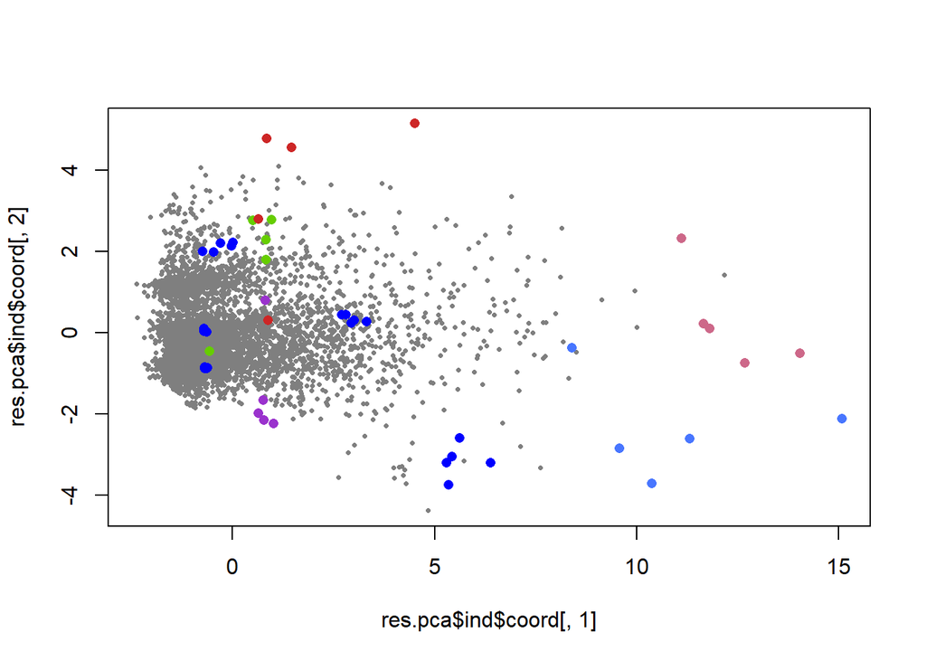

```r
# characteristic individuals
para1<-which(rownames(res.pca$ind$coord)%in%names(res.hcpc$desc.ind$para[[1]]))
dist1<-which(rownames(res.pca$ind$coord)%in%names(res.hcpc$desc.ind$dist[[1]]))
para2<-which(rownames(res.pca$ind$coord)%in%names(res.hcpc$desc.ind$para[[2]]))
dist2<-which(rownames(res.pca$ind$coord)%in%names(res.hcpc$desc.ind$dist[[2]]))
para3<-which(rownames(res.pca$ind$coord)%in%names(res.hcpc$desc.ind$para[[3]]))
dist3<-which(rownames(res.pca$ind$coord)%in%names(res.hcpc$desc.ind$dist[[3]]))
para4<-which(rownames(res.pca$ind$coord)%in%names(res.hcpc$desc.ind$para[[4]]))
dist4<-which(rownames(res.pca$ind$coord)%in%names(res.hcpc$desc.ind$dist[[4]]))
para5<-which(rownames(res.pca$ind$coord)%in%names(res.hcpc$desc.ind$para[[5]]))
dist5<-which(rownames(res.pca$ind$coord)%in%names(res.hcpc$desc.ind$dist[[5]]))

plot(res.pca$ind$coord[,1],res.pca$ind$coord[,2],col="grey50",cex=0.5,pch=16)
points(res.pca$ind$coord[para1,1],res.pca$ind$coord[para1,2],col="blue",cex=1,pch=16)
points(res.pca$ind$coord[dist1,1],res.pca$ind$coord[dist1,2],col="chartreuse3",cex=1,pch=16)
points(res.pca$ind$coord[para2,1],res.pca$ind$coord[para2,2],col="blue",cex=1,pch=16)
points(res.pca$ind$coord[dist2,1],res.pca$ind$coord[dist2,2],col="darkorchid3",cex=1,pch=16)
points(res.pca$ind$coord[para3,1],res.pca$ind$coord[para3,2],col="blue",cex=1,pch=16)
points(res.pca$ind$coord[dist3,1],res.pca$ind$coord[dist3,2],col="firebrick3",cex=1,pch=16)
points(res.pca$ind$coord[para4,1],res.pca$ind$coord[para4,2],col="blue",cex=1,pch=16)
points(res.pca$ind$coord[dist4,1],res.pca$ind$coord[dist4,2],col="palevioletred3",cex=1,pch=16)
points(res.pca$ind$coord[para5,1],res.pca$ind$coord[para5,2],col="blue",cex=1,pch=16)
points(res.pca$ind$coord[dist5,1],res.pca$ind$coord[dist5,2],col="royalblue1",cex=1,pch=16)
```

### Partition quality

We are going to evaluate the partition quality.

#### Gain in inertia (in %)

```r
#res.hcpc$call$t$within[1] = Total sum of squares
#(res.hcpc$call$t$within[1]-res.hcpc$call$t$within[5] = between sum of squares
((res.hcpc$call$t$within[1]-res.hcpc$call$t$within[5])/res.hcpc$call$t$within[1])*100
```

```
## [1] 57.49171
```

The quality of this reduction if of 57.49%.

In case we wanted to achieve an 80% of the clustering representativity we would need 18 clusters.

```r
((res.hcpc$call$t$within[1]-res.hcpc$call$t$within[18])/res.hcpc$call$t$within[1])*100
```

```
## [1] 80.59951
```

### Save the results into dataframe

```r
res.hcpc$call$t$inert.gain[1:5]
```

```
## [1] 1.8187697 0.9105858 0.7460223 0.6120673 0.3712993
```

```r
df$hcpck<-res.hcpc$data.clust$clust
```

# K-Means Classification

## Description of clusters

```r
res.pca <- PCA(df[,c(1:10,12,13,15:17,19,21,22,25,27)],quanti.sup=c(3:6,13),quali.sup=c(1,2,14:16,19:20),ncp=5,graph=FALSE)
ppcc<-res.pca$ind$coord[,1:3] # 3 components principals (kaiser)
dim(ppcc)
```

```
## [1] 4623    3
```

### Optimal number of clusters

```r
library("factoextra")
#fviz_nbclust(ppcc, kmeans, method = "gap_stat")
```

## Classification

```r
dist<-dist(ppcc)  # coordenates are real - Euclidean metric
kc<-kmeans(dist, 5, iter.max=30, trace=TRUE) #caclulate the distances, it turns into a matrix
```

```
## KMNS(*, k=5): iter=  1, indx=3
##  QTRAN(): istep=4623, icoun=0
##  QTRAN(): istep=9246, icoun=52
##  QTRAN(): istep=13869, icoun=6
##  QTRAN(): istep=18492, icoun=13
##  QTRAN(): istep=23115, icoun=1
##  QTRAN(): istep=27738, icoun=9
##  QTRAN(): istep=32361, icoun=27
##  QTRAN(): istep=36984, icoun=7
##  QTRAN(): istep=41607, icoun=49
##  QTRAN(): istep=46230, icoun=1
##  QTRAN(): istep=50853, icoun=6
##  QTRAN(): istep=55476, icoun=2
##  QTRAN(): istep=60099, icoun=777
## KMNS(*, k=5): iter=  2, indx=3
##  QTRAN(): istep=4623, icoun=25
##  QTRAN(): istep=9246, icoun=1
##  QTRAN(): istep=13869, icoun=5
##  QTRAN(): istep=18492, icoun=21
##  QTRAN(): istep=23115, icoun=226
##  QTRAN(): istep=27738, icoun=926
##  QTRAN(): istep=32361, icoun=3
##  QTRAN(): istep=36984, icoun=483
##  QTRAN(): istep=41607, icoun=4591
## KMNS(*, k=5): iter=  3, indx=3
##  QTRAN(): istep=4623, icoun=225
##  QTRAN(): istep=9246, icoun=690
##  QTRAN(): istep=13869, icoun=3645
## KMNS(*, k=5): iter=  4, indx=4623
```

We see from the output that in 4 iterations it has converged. We now procceed to save in the data frame the number of clusters.

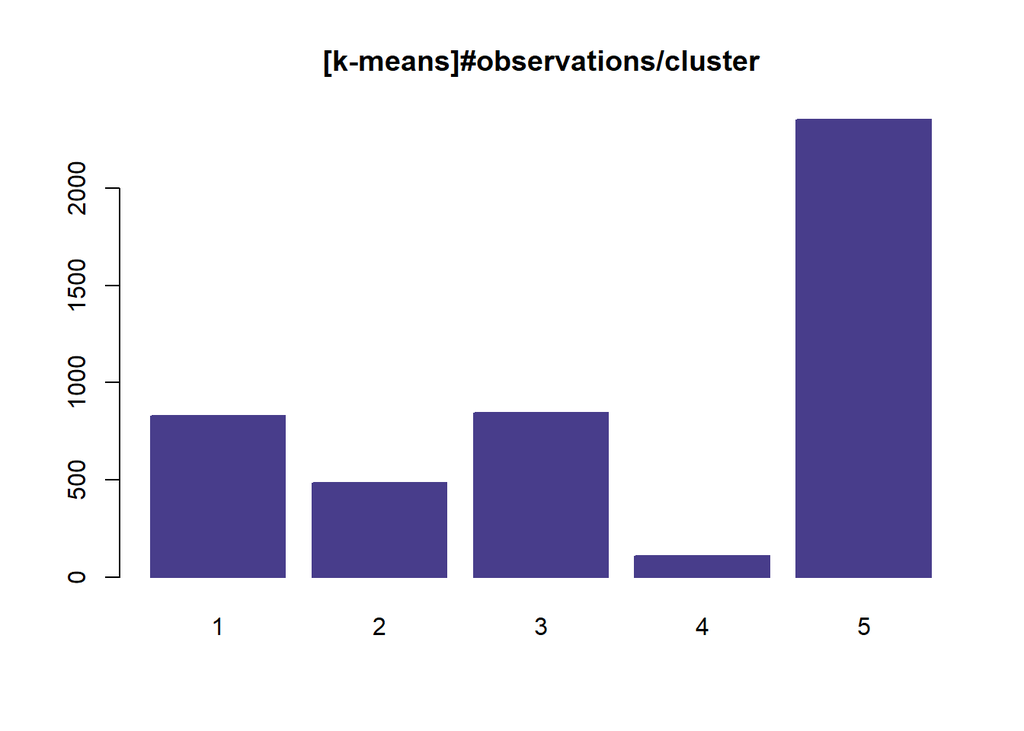

```r
df$claKM<-0
df$claKM<-kc$cluster
df$claKM<-factor(df$claKM)
barplot(table(df$claKM),col="darkslateblue",border="darkslateblue",main="[k-means]#observations/cluster")
```

### Gain in inertia (in %)

```r
100*(kc$betweenss/kc$totss)
```

```
## [1] 79.40953
```

### k-means clusters characteristics

```r
dim(df)
```

```
## [1] 4623   30
```

```r
res.cat <-catdes(df,30)
res.cat
```

```
##
## Link between the cluster variable and the categorical variables (chi-square test)
## =================================================================================
##                             p.value df
## Trip_distance_range    0.000000e+00  8
## paidTolls              0.000000e+00  8
## hcpck                  0.000000e+00 16
## pickup                1.114117e-215 92
## dropoff               4.738913e-206 92
## passenger_groups      1.560774e-177  8
## period                8.756108e-127 12
## TipIsGiven             4.163217e-45  4
## Payment_type           4.711245e-34  8
## RateCodeID             5.628907e-08  4
## MTA_tax                4.996468e-06  4
## improvement_surcharge  3.086294e-05  4
## Trip_type              4.421007e-05  4
##
## Description of each cluster by the categories
## =============================================
## $`1`
##                                   Cla/Mod    Mod/Cla    Global       p.value
## Trip_distance_range=Medium_dist 59.736308 70.8784597 21.328142 9.830260e-273
## hcpck=4                         42.612137 38.8688327 16.396279  5.795841e-70
## Trip_distance_range=Long_dist   30.827068 24.6690734 14.384599  1.510254e-18
## TipIsGiven=Yes                  23.721999 49.6991576 37.659528  5.633107e-15
## Payment_type=Credit card        22.185115 55.9566787 45.338525  1.283731e-11
## paidTolls=No                    18.138112 99.8796631 98.983344  1.064902e-03
## passenger_groups=Single         18.738739 87.6052948 84.036340  1.519643e-03
## pickup=10                       26.701571  6.1371841  4.131516  2.257993e-03
## period=Period night             20.219245 39.9518652 35.518062  3.394570e-03
## pickup=06                       33.333333  2.2864019  1.232966  5.171005e-03
## dropoff=11                      25.396825  5.7761733  4.088254  9.253274e-03
## VendorID=f.Vendor-Mobile        20.452210 23.9470517 21.046939  2.509928e-02
## dropoff=21                      22.932331  7.3405535  5.753839  3.468393e-02
## VendorID=f.Vendor-VeriFone      17.315068 76.0529483 78.953061  2.509928e-02
## pickup=17                       12.749004  3.8507822  5.429375  2.247023e-02
## dropoff=17                      12.648221  3.8507822  5.472637  1.935138e-02
## hcpck=2                         15.973072 31.4079422 35.345014  8.402245e-03
## pickup=16                       12.323944  4.2117930  6.143197  8.066705e-03
```

[output cut: 570 more lines]

```
## Dropoff_latitude   0.05512875  2.546951e-09
## Pickup_latitude    0.05527371  1.558026e-06
## Dropoff_longitude  0.04455396  1.324096e-03
## Pickup_longitude   0.04124656  1.014166e-02
## hour               6.78263699  4.925237e-10
## Tolls_amount       0.50523041  6.388760e-11
## espeed             8.70570362  6.158740e-54
## Tip_amount         1.83366715  2.369546e-87
## Passenger_count    1.03565723  1.924230e-96
## Extra              0.36668354 4.963017e-158
## tlenkm             4.50528246 1.712776e-225
## Trip_distance      2.78356770 4.466041e-228
## traveltime        10.03175633 1.202241e-239
## Total_amount      10.04487145 2.653016e-249
## Fare_amount        8.25496368 3.301578e-258
```

### Comparison of clusters (confusion table)

We want to compare the hierarchical clustering, previously done, and the kmeans clustering, so proceed to do the following.

```r
table(df$hcpck,df$claKM)
```

```
##
##        1    2    3    4    5
##   1  239    7  694    0  990
##   2  261    2    8    0 1363
##   3    8  111  142    1    0
##   4  323  366    0   69    0
##   5    0    0    0   39    0
```

```r
# we must do a relabel
df$hcpck<-factor(df$hcpck,labels=c("kHP-1","kHP-2","kHP-3","kHP-4","kHP-5"))
df$claKM<-factor(df$claKM,levels=c(3,5,2,1,4),labels=c("kKM-3","kKM-5","kKM-2","kKM-1","kKM-4"))
tt<-table(df$hcpck,df$claKM); tt
```

```
##
##         kKM-3 kKM-5 kKM-2 kKM-1 kKM-4
##   kHP-1   694   990     7   239     0
##   kHP-2     8  1363     2   261     0
##   kHP-3   142     0   111     8     1
##   kHP-4     0     0   366   323    69
##   kHP-5     0     0     0     0    39
```

```r
100*sum(diag(tt)/sum(tt))
```

```
## [1] 54.72637
```

We have a concordance of the 54.73% so we can say that they are different, if we had a greater concordance, this would mean that they would be more similar.

# CA analysis

## Are there any row categories that can be combined/avoided to explain the discretization of the numeric target.

### CA analysis for your data should contain your factor version of the numeric target (previous) in K= 7 (maximum 10) levels and 2 factors.

The first thing we need to do is factor our numeric target variable, Total_amount, and name it f.cost. We are going to set 6 different categories.

```r
df$f.cost[df$Total_amount<=8] = "[0,8]"
df$f.cost[(df$Total_amount>8) & (df$Total_amount<=11)] = "(8,11]"
df$f.cost[(df$Total_amount>11) & (df$Total_amount<=18)] = "(11,18]"
df$f.cost[(df$Total_amount>18) & (df$Total_amount<= 30)] = "(18,30]"
df$f.cost[(df$Total_amount>30) & (df$Total_amount<= 50)] = "(30,50]"
df$f.cost[df$Total_amount>50] = "(50,129)"
df$f.cost<-factor(df$f.cost)
table(df$f.cost)
```

```
##
##  (11,18]  (18,30]  (30,50] (50,129)   (8,11]    [0,8]
##     1188      724      221       63     1151     1276
```

```r
tt<-table(df[,c("f.cost","passenger_groups")]);tt
```

```
##           passenger_groups
## f.cost     Couple Group Single
##   (11,18]      77    89   1022
##   (18,30]      58    72    594
##   (30,50]      20    20    181
##   (50,129)      5     7     51
##   (8,11]       81   104    966
##   [0,8]       102   103   1071
```

```r
chisq.test(tt,  simulate.p.value = TRUE) #to see if the rows and columns are independents. H0: Rows and columns are independent
```

```
##
##  Pearson's Chi-squared test with simulated p-value (based on 2000
##  replicates)
##
## data:  tt
## X-squared = 8.8677, df = NA, p-value = 0.5212
```

We are now going to take a look to the simple correspondences.

```r
res.ca <- CA(tt)
```

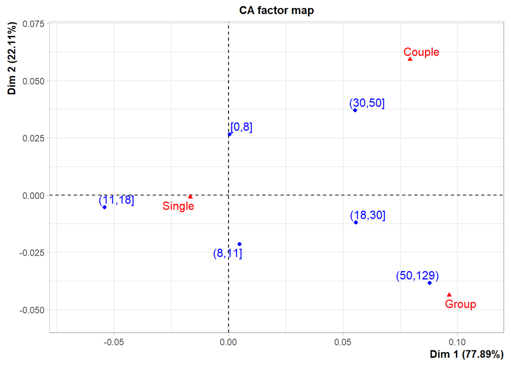

Those observations far away from the gravity center will mean that represent less observations on the sample. If rows and columns are nearby, this will mean that there is a correspondence between them, which means that they occur simultaneously in the sample.

```r
summary(res.ca)
```

```
##
## Call:
## CA(X = tt)
##
## The chi square of independence between the two variables is equal to 8.867721 (p-value =  0.5447017 ).
##
## Eigenvalues
##                        Dim.1   Dim.2
## Variance               0.001   0.000
## % of var.             77.890  22.110
## Cumulative % of var.  77.890 100.000
##
## Rows
##            Iner*1000    Dim.1    ctr   cos2    Dim.2    ctr   cos2
## (11,18]  |     0.759 | -0.054 50.310  0.990 | -0.005  1.763  0.010 |
## (18,30]  |     0.507 |  0.056 32.461  0.956 | -0.012  5.273  0.044 |
## (30,50]  |     0.212 |  0.055  9.782  0.691 |  0.037 15.413  0.309 |
## (50,129) |     0.125 |  0.088  7.047  0.839 | -0.038  4.746  0.161 |
## (8,11]   |     0.120 |  0.005  0.396  0.049 | -0.021 26.828  0.951 |
## [0,8]    |     0.195 |  0.000  0.004  0.000 |  0.027 45.976  1.000 |
##
## Columns
##            Iner*1000    Dim.1    ctr   cos2    Dim.2    ctr   cos2
## Couple   |     0.726 |  0.079 31.197  0.642 |  0.059 61.383  0.358 |
## Group    |     0.955 |  0.096 52.961  0.829 | -0.044 38.494  0.171 |
## Single   |     0.237 | -0.017 15.841  0.998 | -0.001  0.122  0.002 |
```

We conclude that we can not reject the H0 for these pair of factors, and now we are going to see if we can see if there is independence between the cost and the travel time, so the first thing we are going to do is factor the travel time.

```r
df$f.tt[df$traveltime<=5] = "[0,5]"
df$f.tt[(df$traveltime>5) & (df$traveltime<=10)] = "(5,10]"
df$f.tt[(df$traveltime>10) & (df$traveltime<=15)] = "(10,15]"
df$f.tt[(df$traveltime>15) & (df$traveltime<= 20)] = "(15,20]"
df$f.tt[(df$traveltime>20) & (df$traveltime<= 50)] = "(20,50]"
df$f.tt<-factor(df$f.tt)
table(df$f.tt)
```

```
##
## (10,15] (15,20] (20,50]  (5,10]   [0,5]
##     913     549     694    1511     894
```

Once we have this factor, proceed to create a variable that associates the cost with the traveltime.

```r
tt<-table(df[,c("f.cost","f.tt")]);tt
```

```
##           f.tt
## f.cost     (10,15] (15,20] (20,50] (5,10] [0,5]
##   (11,18]      613     314      88    156     8
##   (18,30]      106     205     388      3    15
##   (30,50]        1      23     175      2     4
##   (50,129)       1       1      35      0     7
##   (8,11]       189       3       4    864    85
##   [0,8]          3       3       4    486   775
```

```r
chisq.test(tt) #to see if the rows and columns are independents. H0: Rows and columns are independent
```

```
##
##  Pearson's Chi-squared test
##
## data:  tt
## X-squared = 6099.3, df = 20, p-value < 2.2e-16
```

We get a p-value smaller than 0.05 so we can reject the H0. ((< 2.2e-16) < 0.05). So there is dependence between the traveltime and the cost, as we suspected.

We are now going to take a look to the simple correspondences.

```r
res.ca <- CA(tt)
```

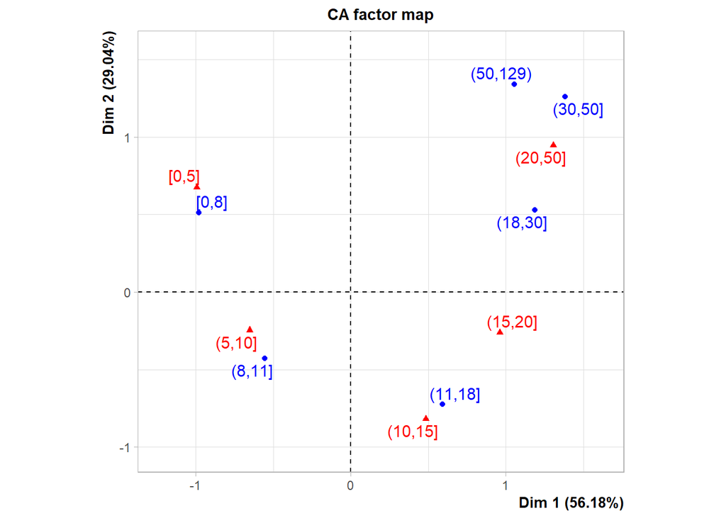

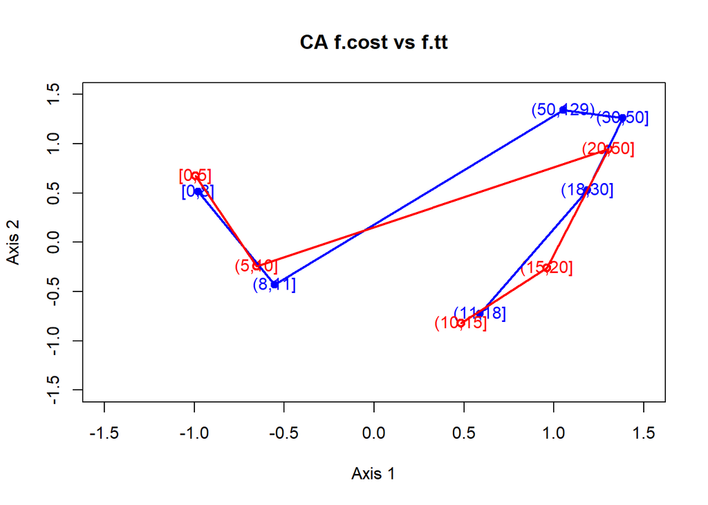

```r
plot(res.ca$row$coord[,1],res.ca$row$coord[,2],pch=19,col="blue",xlim=c(-1.5,1.5),ylim=c(-1.5,1.5),xlab="Axis 1",ylab="Axis 2", main="CA f.cost vs f.tt")
points(res.ca$col$coord[,1],res.ca$col$coord[,2],lwd=2,col="red")
text(res.ca$row$coord[,1],res.ca$row$coord[,2],lwd=2,col="blue",labels=levels(df$f.cost))
text(res.ca$col$coord[,1],res.ca$col$coord[,2],lwd=2,col="red",labels=levels(df$f.tt))
lines(res.ca$row$coord[,1],res.ca$row$coord[,2],lwd=2,col="blue")
lines(res.ca$col$coord[,1],res.ca$col$coord[,2],lwd=2,col="red")
```

We can see in the plot, clearly that there are some categories that occur simultaneously in the sample, for instant the trips up to 5 minutes with the cost up to 8, the trips between 5-10 minutes and the costs between 8-11, the same happen with the trips between 10-15 minutes and the costs between 11-18. There is a clear relation between the f.cost and f.tt categories, even though we can not see a Guttman’s effect from manual the relation is there.

```r
summary(res.ca)
```

```
##
## Call:
## CA(X = tt)
##
## The chi square of independence between the two variables is equal to 6099.333 (p-value =  0 ).
##
## Eigenvalues
##                        Dim.1   Dim.2   Dim.3   Dim.4
## Variance               0.751   0.388   0.189   0.009
## % of var.             56.176  29.038  14.129   0.656
## Cumulative % of var.  56.176  85.215  99.344 100.000
##
## Rows
##            Iner*1000     Dim.1     ctr    cos2     Dim.2     ctr    cos2
## (11,18]  |   266.105 |   0.590  11.967   0.338 |  -0.726  35.079   0.512 |
## (18,30]  |   269.624 |   1.187  29.477   0.821 |   0.529  11.324   0.163 |
## (30,50]  |   175.119 |   1.383  11.441   0.491 |   1.260  18.373   0.407 |
## (50,129) |    31.782 |   1.054   1.425   0.337 |   1.341   4.467   0.546 |
## (8,11]   |   221.698 |  -0.553  10.223   0.346 |  -0.429  11.924   0.209 |
## [0,8]    |   372.951 |  -0.978  35.466   0.714 |   0.512  18.833   0.196 |
##            Dim.3     ctr    cos2
## (11,18]    0.391  20.884   0.148 |
## (18,30]   -0.063   0.333   0.002 |
## (30,50]   -0.582   8.062   0.087 |
## (50,129)  -0.419   0.895   0.053 |
## (8,11]    -0.627  52.158   0.445 |
## [0,8]      0.346  17.668   0.090 |
##
## Columns
##            Iner*1000     Dim.1     ctr    cos2     Dim.2     ctr    cos2
## (10,15]  |   200.286 |   0.483   6.218   0.233 |  -0.819  34.577   0.670 |
## (15,20]  |   143.488 |   0.960  14.763   0.773 |  -0.260   2.095   0.057 |
## (20,50]  |   415.261 |   1.305  34.509   0.624 |   0.946  35.059   0.328 |
## (5,10]   |   236.860 |  -0.653  18.786   0.596 |  -0.246   5.145   0.084 |
## [0,5]    |   341.385 |  -0.993  25.724   0.566 |   0.677  23.123   0.263 |
##            Dim.3     ctr    cos2
## (10,15]    0.288   8.805   0.083 |
## (15,20]    0.398  10.107   0.133 |
## (20,50]   -0.357  10.289   0.047 |
## (5,10]    -0.477  39.954   0.319 |
## [0,5]      0.545  30.844   0.171 |
```

The first thing we can see from the summary is that we have a chi square statistic of 6099.333, great enough to reject the H0, which means the intensity of the relation is high. If we take a look at the variances from the different dimensions, we can see that all together sum more than 1.

## Eigenvalues and dominant axes analysis. How many axes we have to consider?

```r
mean(res.ca$eig[,1])
```

```
## [1] 0.3343199
```

# MCA analysis

The Multiple correspondence analysis (MCA) is an extension of the simple correspondence analysis for summarizing and visualizing a data table containing more than two categorical variables.

MCA is generally used to analyse a data set from survey. The goal is to identify:

- A group of individuals with similar profile in their answers to the questions
- The associations between variable categories

First, we load the libraries we’ll use:

```r
library(FactoMineR)
library(factoextra)
```

Now, we can start computing the MCA for our categorical variables:

```r
res.mca <- MCA(
  df[,c(1:2,15:17,19,25,27:28,31)],
  quanti.sup=c(3),
  quali.sup=c(8,10),
  graph=FALSE
)
```

Let’s look at the supplementary quantitative variable Total_amount. We can see that it is closer to the Dim2 than to the Dim1.

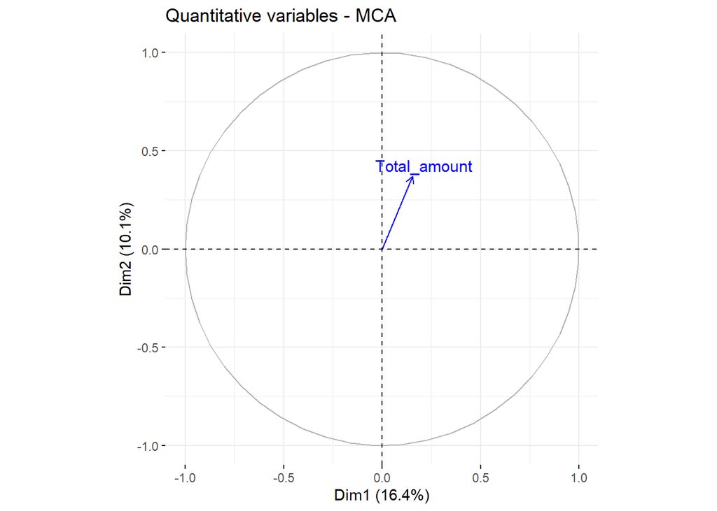

```r
fviz_mca_var(res.mca, choice="quanti.sup", repel=TRUE, ggtheme=theme_minimal())
```

Cloud of individuals:

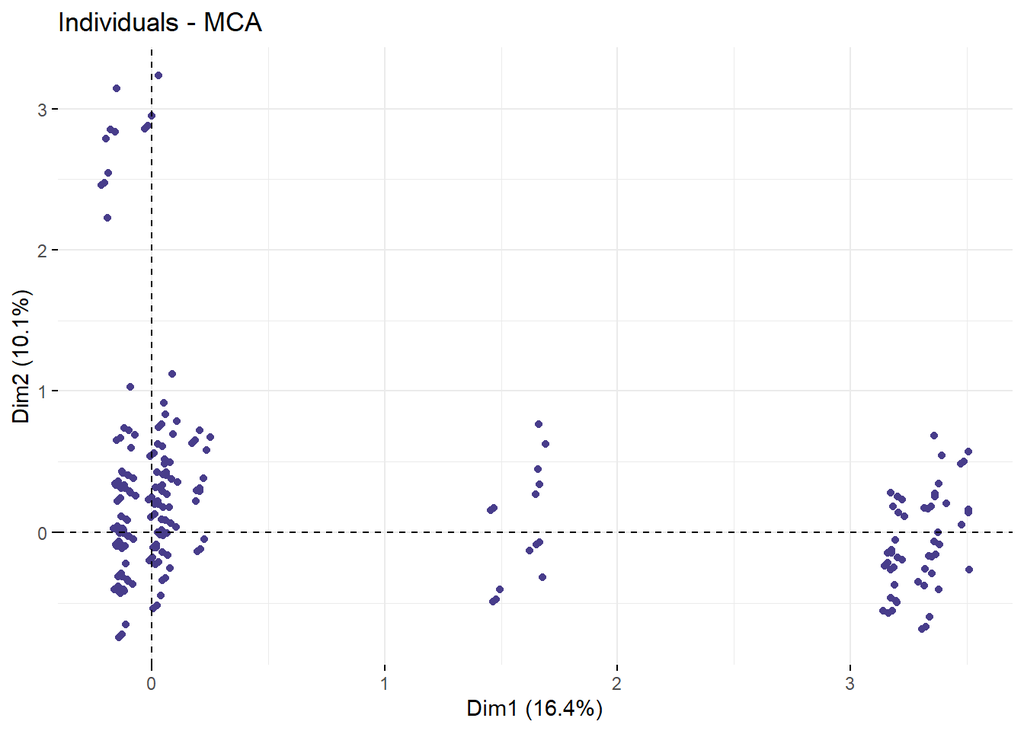

```r
fviz_mca_ind(
  res.mca,
  geom=c("point"),
  col.ind="darkslateblue"
)
```

## Eigenvalues and dominant axes analysis

*How many axes we have to consider for next Hierarchical Classification stage?* We consider, according to the generalized Kaiser theorem, all those dimensions such that their eigenvalue is greater than the mean. We see that the average gives us 0.1428571. Therefore, we will take up to dimension 6, which represents the 62.07% of the sample.

```r
mean(res.mca$eig[,1])
```

```
## [1] 0.1428571
```

```r
head(get_eigenvalue(res.mca), 10)
```

```
##        eigenvalue variance.percent cumulative.variance.percent
## Dim.1   0.2817102        16.433095                    16.43310
## Dim.2   0.1727341        10.076157                    26.50925
## Dim.3   0.1676074         9.777097                    36.28635
## Dim.4   0.1523716         8.888343                    45.17469
## Dim.5   0.1459733         8.515108                    53.68980
## Dim.6   0.1436861         8.381688                    62.07149
## Dim.7   0.1396003         8.143350                    70.21484
## Dim.8   0.1375543         8.024001                    78.23884
## Dim.9   0.1304320         7.608536                    85.84738
## Dim.10  0.1179063         6.877867                    92.72524
```

We can also visualize the percentages of inertia explained by each MCA dimensions:

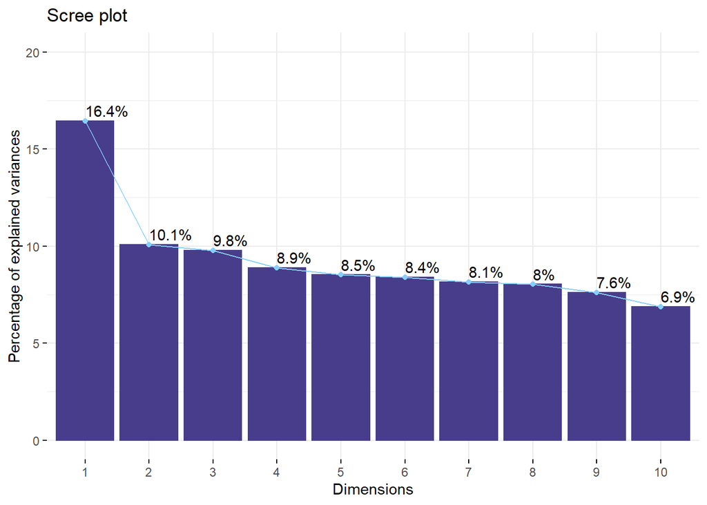

```r
fviz_screeplot(
  res.mca,
  addlabels=TRUE,
  ylim=c(0,20),
  barfill="darkslateblue",
  barcolor="darkslateblue",
  linecolor="skyblue1"
)
```

## Individuals point of view

Are they any individuals “too contributive”?

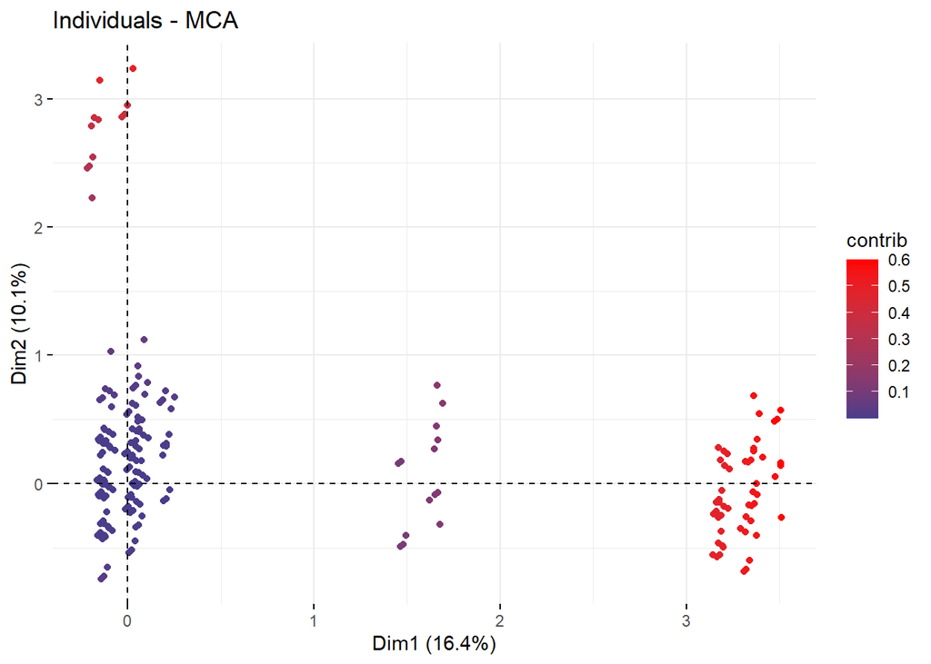

```r
fviz_mca_ind(
  res.mca,
  geom=c("point"),
  col.ind="contrib",
  gradient.cols=c("darkslateblue", "red")
)
```

Are there any groups?

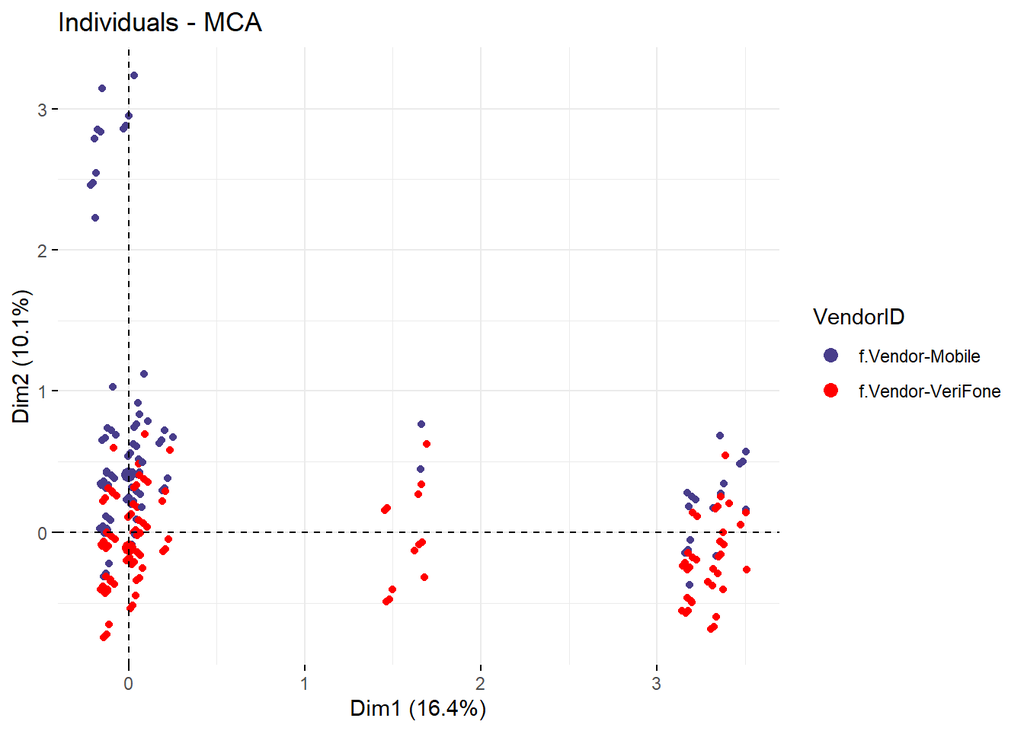

```r
fviz_mca_ind(res.mca, label="none", habillage="VendorID", palette=c("darkslateblue", "red"))
```

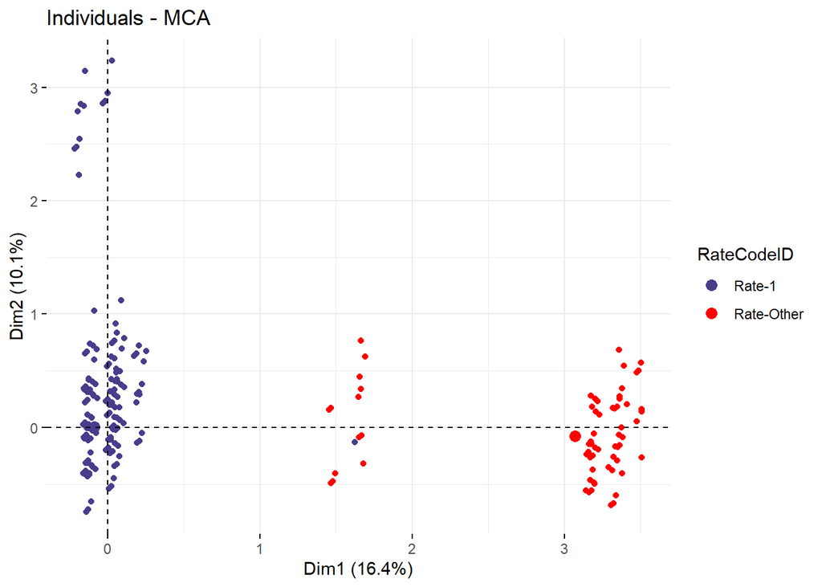

```r
fviz_mca_ind(res.mca, label="none", habillage="RateCodeID", palette=c("darkslateblue", "red"))
```

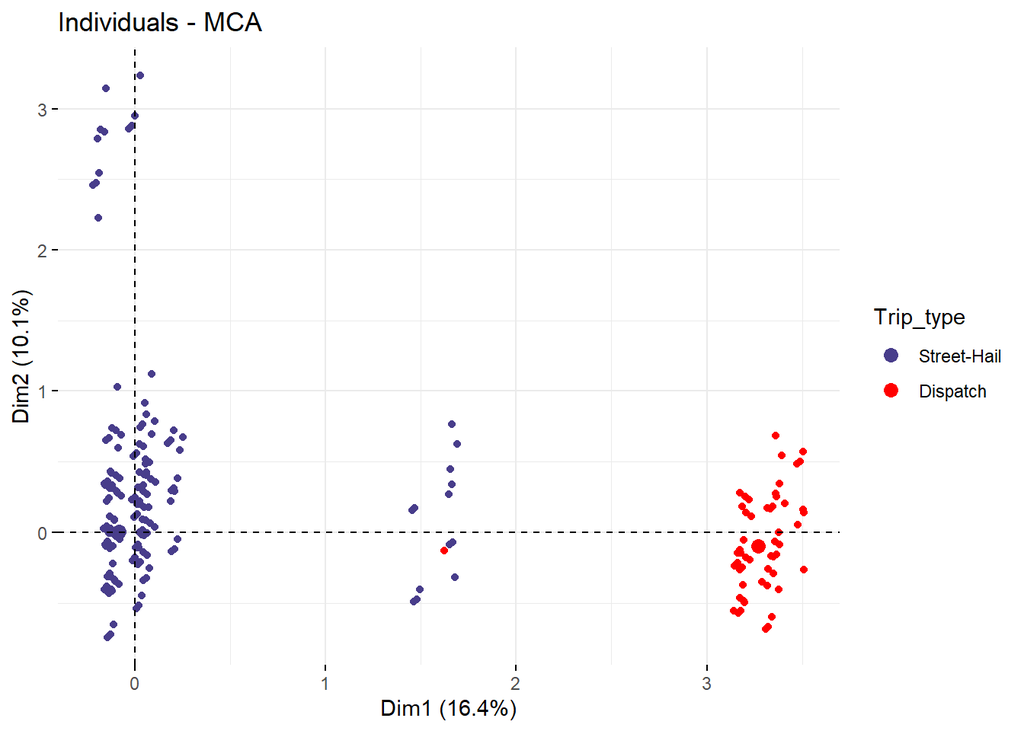

```r
fviz_mca_ind(res.mca, label="none", habillage="Trip_type", palette=c("darkslateblue", "red"))
```

We can see that individuals are more grouped according to some variables than others. For example, the f.VendorID-Mobile is along the entire dimension 1 but also in the center of gravity. In contrast, the Rate-Other is only in the first dimension and does not touch the second at all.

## Interpreting map of categories: average profile versus extreme profiles (rare categories)

Before looking at the categories, let’s look at its variables:

As we can see in the plot “Variables representation”, the correlation between the Payment_type factor taking into account the eta2 and the second factorial axis is a value greater than 0.5. On the other hand, we can see that something similar happens with the Trip_type factor and RateCodeID in dimension 1.

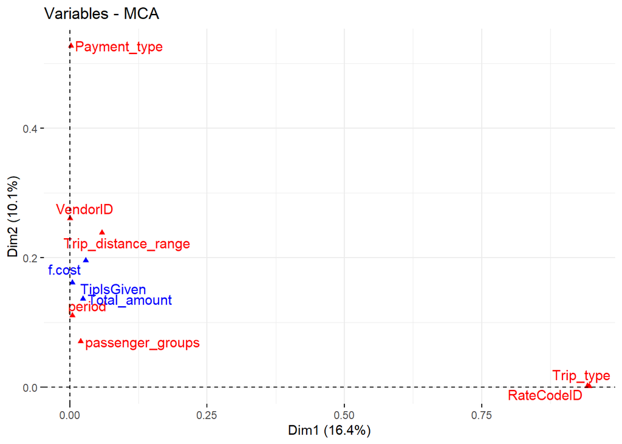

```r
fviz_mca_var(res.mca, choice="mca.cor", repel=TRUE)
```

Now, let’s analyze the categories.

As we can see, the “No paid” category (“Payment_type” variable) is the one farthest from the center of the plot (in dimension 2). The farther from the center of gravity, the more rarely this feature value appears in the sample represented by the dimension. In addition, we see that in dimension 1 we also have two extremes, the “Rate-Other” category (“RateCodeID” variable) and the “Dispatch” category (“Trip_type” variable). As we have said, this means that these categories are rarely represented in this dimension.

Regardering the center of mass, we can say that we find the categories most represented by the dimensions.

To give an example, let’s suppose we look at the first dimension. An observation that we could find with high probability would be the following:

- RateCodeID = Rate-1
- Trip_type = Street-Hail

On the other hand, an observation that we could rarely find there would be…

- RateCodeID = Rate-Other
- Trip_type = Street-Dispatch

We would follow the same logic for dimension 2 considering the Payment_type variable.

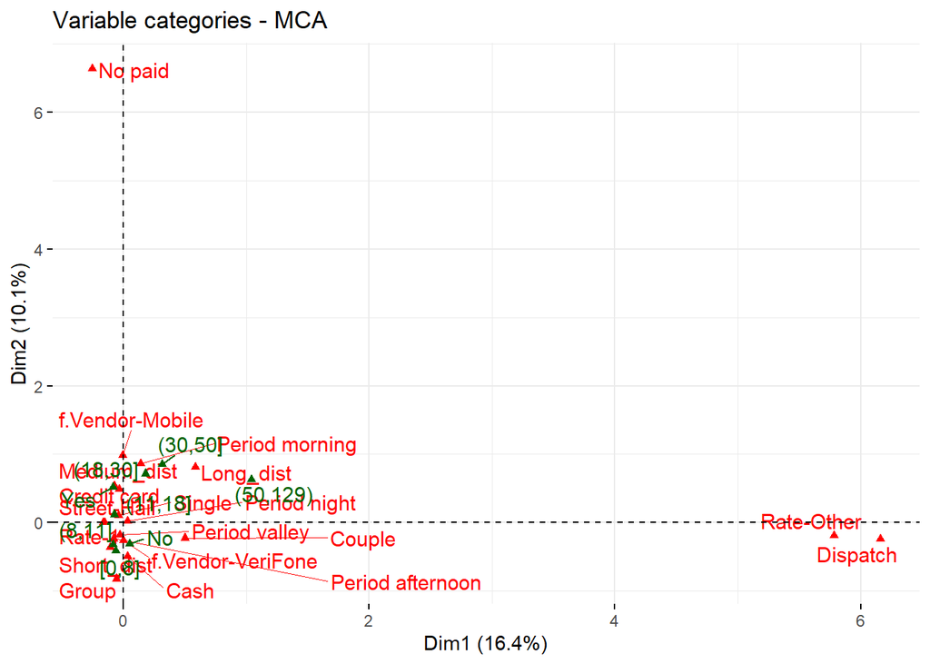

```r
fviz_mca_var(res.mca, repel=TRUE)
```

## Interpreting the axes association to factor map

```r
res.desc <- dimdesc(res.mca, axes = c(1,2))
```

### Description of dimension 1

```r
res.desc[[1]]
```

```
## $quanti
##              correlation     p.value
## Total_amount   0.1547222 3.65431e-26
##
## $quali
##                              R2      p.value
## RateCodeID          0.945537593 0.000000e+00
## Trip_type           0.942072409 0.000000e+00
## Trip_distance_range 0.058205469 6.898258e-61
## f.cost              0.028972784 1.405425e-27
## passenger_groups    0.019901125 6.814707e-21
## TipIsGiven          0.004240936 9.364240e-06
## period              0.004628593 8.564400e-05
## Payment_type        0.001608040 2.429314e-02
##
## $category
##                                    Estimate      p.value
## Trip_type=Dispatch               1.67529735 0.000000e+00
## RateCodeID=Rate-Other            1.57877258 0.000000e+00
## Trip_distance_range=Long_dist    0.24028354 4.637674e-62
## passenger_groups=Couple          0.19279452 5.856637e-22
## f.cost=(50,129)                  0.43727781 5.906344e-17
## f.cost=(30,50]                   0.05054341 1.602061e-06
## TipIsGiven=No                    0.03566808 9.364240e-06
## period=Period morning            0.06536718 5.700992e-04
## Payment_type=Cash                0.06349408 1.434472e-02
## Payment_type=Credit card         0.02679756 2.616189e-02
## f.cost=[0,8]                    -0.14970203 8.537458e-03
## Trip_distance_range=Medium_dist -0.11215628 6.996595e-03
## f.cost=(11,18]                  -0.15476359 3.894367e-03
## period=Period afternoon         -0.05178612 1.144725e-03
## f.cost=(8,11]                   -0.16266832 6.499724e-04
## TipIsGiven=Yes                  -0.03566808 9.364240e-06
## f.cost=(18,30]                  -0.02068728 1.202545e-07
## passenger_groups=Single         -0.09190735 2.059738e-09
## Trip_distance_range=Short_dist  -0.12812726 2.015102e-22
## Trip_type=Street-Hail           -1.67529735 0.000000e+00
## RateCodeID=Rate-1               -1.57877258 0.000000e+00
##
## attr(,"class")
## [1] "condes" "list "
```

In the first dimension we see that for the **qualitative** variables the most positively related, from more to less, are:

- RateCodeID (0.95)
- Trip_type (0.94)

### Description of dimension 2

```r
res.desc[[2]]
```

```
## $quanti
##              correlation       p.value
## Total_amount   0.3688482 5.757656e-149
##
## $quali
##                               R2       p.value
## Payment_type        0.5272544813  0.000000e+00
## VendorID            0.2602830667 6.879178e-305
## Trip_distance_range 0.2384878813 4.714678e-274
## f.cost              0.1956079989 4.287815e-215
## TipIsGiven          0.1613968295 6.956769e-179
## period              0.1103532182 9.429917e-117
## passenger_groups    0.0703669803  6.304633e-74
## Trip_type           0.0013941924  1.111798e-02
## RateCodeID          0.0009990214  3.163284e-02
##
## $category
##                                    Estimate       p.value
## Payment_type=No paid             1.84096016  0.000000e+00
## VendorID=f.Vendor-Mobile         0.26007767 6.879178e-305
## TipIsGiven=Yes                   0.17229953 6.956769e-179
## Trip_distance_range=Long_dist    0.19939818 5.880829e-119
## period=Period morning            0.30980763 1.193381e-106
## f.cost=(18,30]                   0.18702736 1.831882e-102
## Trip_distance_range=Medium_dist  0.08653538  8.235254e-84
## passenger_groups=Single          0.17356325  4.157410e-60
## f.cost=(30,50]                   0.24385380  3.076322e-39
## f.cost=(50,129)                  0.15326671  3.834075e-07
## passenger_groups=Couple          0.03719691  1.495679e-05
## Trip_type=Street-Hail            0.05046600  1.111798e-02
## RateCodeID=Rate-1                0.04018420  3.163284e-02
## RateCodeID=Rate-Other           -0.04018420  3.163284e-02
## Trip_type=Dispatch              -0.05046600  1.111798e-02
## f.cost=(11,18]                  -0.06069884  1.647278e-06
## period=Period valley            -0.12396133  4.566127e-14
## period=Period afternoon         -0.14612741  8.436539e-21
## f.cost=(8,11]                   -0.24322507  1.869439e-36
## passenger_groups=Group          -0.21076016  2.204053e-67
## f.cost=[0,8]                    -0.28022396  5.282753e-68
## TipIsGiven=No                   -0.17229953 6.956769e-179
## Payment_type=Credit card        -0.71587782 4.558246e-227
## Trip_distance_range=Short_dist  -0.28593356 2.059524e-267
## VendorID=f.Vendor-VeriFone      -0.26007767 6.879178e-305
## Payment_type=Cash               -1.12508234  0.000000e+00
##
## attr(,"class")
## [1] "condes" "list "
```

For the second dimension we see that for the **qualitative** variables the most positively related, from more to less, are:

- Payment_type (0.53)
- VendorID (0.26)

We see that they are not very large numbers, however.

If we look at the **categories**, we see that the most related are,

- for Payment_type:
  - No paid (1.84)
- and for VendorID:
  - f.Vendor-Mobile (0.26)

## Perform a MCA taking into account also supplementary variables (use all numeric variables) quantitative and/or categorical. How supplementary variables enhance the axis interpretation?

```r
res.mca_all <- MCA(
  df[,c(1:32)],
  quanti.sup=c(3:10, 12:13, 15, 18, 20:22),
  quali.sup=c(27,31),
  graph=FALSE
)
```

### Description of dimensions

```r
res.desc <- dimdesc(res.mca_all, axes = c(1,2))
```

#### Description of dimension 1

```r
res.desc[[1]]
```

```
## $quanti
##                  correlation       p.value
## Fare_amount       0.34704329 5.687723e-131
## Trip_distance     0.31264071 2.305988e-105
## Total_amount      0.28704716  2.116125e-88
## tlenkm            0.28360598  2.991362e-86
## traveltime        0.23128431  3.455149e-57
## espeed            0.18449624  1.122581e-36
## Tolls_amount      0.11567250  3.040161e-15
## Tip_amount        0.10081884  6.393352e-12
## Pickup_latitude   0.09471249  1.100053e-10
## Dropoff_latitude  0.08750941  2.525109e-09
## Pickup_longitude  0.04599144  1.760667e-03
## Passenger_count  -0.06437422  1.184978e-05
## hour             -0.20861841  1.253392e-46
## Extra            -0.46952211 3.175111e-252
##
## $quali
##                                R2       p.value
## RateCodeID            0.693923341  0.000000e+00
## MTA_tax               0.711903229  0.000000e+00
## improvement_surcharge 0.698232732  0.000000e+00
## Trip_type             0.708486163  0.000000e+00
## hcpck                 0.297939266  0.000000e+00
## dropoff               0.209345234 3.392119e-214
## pickup                0.207487287 6.821630e-212
## period                0.164815275 5.012350e-180
## claKM                 0.163714821 1.972284e-177
## Trip_distance_range   0.136491381 5.970680e-148
## f.cost                0.102309739 1.704572e-105
## f.tt                  0.076192183  6.211428e-77
## paidTolls             0.019509924  1.713157e-20
## passenger_groups      0.006558016  2.507248e-07
##
## $category
##                                                    Estimate       p.value
## Trip_type=Dispatch                               1.43031511  0.000000e+00
## improvement_surcharge=improvement_surcharge_No   1.38427751  0.000000e+00
## MTA_tax=MTA_tax_No                               1.39203218  0.000000e+00
## RateCodeID=Rate-Other                            1.33153381  0.000000e+00
```

[output cut: 66 more lines]

```
## pickup=pickup_18                                -0.33381152  2.133837e-23
## dropoff=dropoff_18                              -0.33632575  1.896016e-23
## f.cost=(8,11]                                   -0.31365948  7.123600e-25
## f.tt=(5,10]                                     -0.22721770  1.228615e-33
## Trip_distance_range=Short_dist                  -0.23435829  4.137407e-87
## period=Period afternoon                         -0.31848308  1.175534e-87
## claKM=kKM-3                                     -0.49342136 5.050918e-128
## hcpck=kHP-1                                     -0.44624768 2.882408e-285
## Trip_type=Street-Hail                           -1.43031511  0.000000e+00
## improvement_surcharge=improvement_surcharge_Yes -1.38427751  0.000000e+00
## MTA_tax=MTA_tax_Yes                             -1.39203218  0.000000e+00
## RateCodeID=Rate-1                               -1.33153381  0.000000e+00
##
## attr(,"class")
## [1] "condes" "list "
```

In this dimension, since we have taken into account all the variables, we now have information for the **quantitative** variables. We see that, more or less, the most positively related are:

- Fare_amount (0.35)
- Trip_distance (0.31)
- Total_amount (0.29)

We also see that they do not contribute much given the numbers.

However, there is a little more inverse relationship with Extra, with a -0.47.

Regarding the **qualitative** variables, the new relationship is as follows:

- RateCodeID (0.69)
- MTA_tax (0.71)
- improvement_surcharge (0.70)
- Trip_type (0.71)

If we look at the **categories**, we see that the most related are,

- for Trip_type:
  - Dispatch (1.43) -> same as before but less related
- for improvement_surcharge:
  - improvement_surcharge_No (1.38)
- for MTA_tax:
  - MTA_tax_No (1.39)
- for Trip_distance_range:
  - Long_dist (0.24)
- and for RateCodeID:
  - Rate-Other (1.33) -> same as before but less related

#### Description of dimension 2

```r
res.desc[[2]]
```

```
## $quanti
##                   correlation      p.value
## Extra              0.59540871 0.000000e+00
## Passenger_count    0.18753711 7.367467e-38
## hour               0.14546401 2.768090e-23
## Dropoff_longitude  0.10780500 1.991105e-13
## espeed             0.10518904 7.497280e-13
## Pickup_longitude   0.08329485 1.413350e-08
## Total_amount       0.04423863 2.624881e-03
## Trip_distance      0.04404583 2.740527e-03
## Fare_amount        0.03440690 1.931080e-02
## tlenkm             0.03204240 2.936007e-02
## traveltime        -0.03531017 1.635340e-02
## Tolls_amount      -0.05868397 6.539683e-05
## Dropoff_latitude  -0.08128077 3.127258e-08
## Pickup_latitude   -0.08469170 8.059026e-09
##
## $quali
##                                 R2       p.value
## period                0.7193448269  0.000000e+00
## pickup                0.7762688275  0.000000e+00
## dropoff               0.7624477783  0.000000e+00
## hcpck                 0.4545819701  0.000000e+00
## MTA_tax               0.1619886885 1.358849e-179
## Trip_type             0.1582247481 4.316437e-175
## improvement_surcharge 0.1533670876 2.604975e-169
## RateCodeID            0.1514542007 4.820984e-167
## claKM                 0.1244134404 1.691964e-131
## passenger_groups      0.0437705123  1.254658e-45
## f.cost                0.0076558568  1.198591e-06
## Trip_distance_range   0.0055181933  2.809998e-06
## paidTolls             0.0044565106  3.304810e-05
## f.tt                  0.0041361451  1.808199e-03
## VendorID              0.0009197986  3.920678e-02
## Payment_type          0.0012977242  4.980251e-02
##
## $category
##                                                    Estimate       p.value
## hcpck=kHP-1                                      0.31938183  0.000000e+00
## period=Period night                              0.40222038 3.365631e-247
```

[output cut: 69 more lines]

```
## claKM=kKM-5                                     -0.15911679  1.682905e-71
## pickup=pickup_15                                -0.54732996  3.165865e-72
## dropoff=dropoff_15                              -0.55708943  1.053768e-72
## pickup=pickup_14                                -0.61682332  1.161024e-92
## dropoff=dropoff_14                              -0.63592139  2.251034e-94
## RateCodeID=Rate-1                               -0.57687316 4.820984e-167
## improvement_surcharge=improvement_surcharge_Yes -0.60163400 2.604975e-169
## Trip_type=Street-Hail                           -0.62682523 4.316437e-175
## MTA_tax=MTA_tax_Yes                             -0.61577827 1.358849e-179
## period=Period morning                           -0.47130282 8.452319e-206
## hcpck=kHP-2                                     -0.40169174  0.000000e+00
## period=Period valley                            -0.38974292  0.000000e+00
##
## attr(,"class")
## [1] "condes" "list "
```

In this dimension, since we have taken into account all the variables, we now have information for the **quantitative** variables. We see that, more or less, the most positively related are:

- Extra (0.59540871)
- Passenger_count (0.18753711)

If we look at the **categories**, we see that the most related are,

- for period:
  - Period night (0.40)
  - Period afternoon (0.46)
- …
- for Payment_type:
  - No paid (1.84) -> now it’s inversed
- and for VendorID:
  - f.Vendor-Mobile -> it does not even appear